# Brain stroke

# 1. Problem

Worldwide, brain stroke is the second leading cause of death and third leading cause of disability . As per the recent data, in India, every 3 people suffer from brain stroke every minute. we chose this data set so it can be used to improve and enhance medical knowledge,develop more effective prevention strategies about this disease,enhance treatment options,and reduce the prevalence and impact of brain stroke on society and spread awaeness.

The Problem statement: To use data mining techniques to help researchers for early detection, risk assessment, and improved understanding of brain strokes, explore the given dataset on brain stroke and develop a predictive model that can identify the key risk factors associated with stroke. Specifically, the project aims to:

1. Perform exploratory data analysis to gain insights into the distribution and characteristics of the variables in the dataset.
2. Identify the most significant variables and their relationships with stroke occurrence using statistical analysis and data visualization techniques.
3. Preprocess the dataset by handling missing values, outliers, and categorical variables, ensuring data quality and consistency.
4. Select appropriate data mining techniques, such as classification algorithms, to build a predictive model for stroke risk assessment.

# 2. Datamining task

Our goal of collecting a dataset about brain stroke is to gather relevant and accurate information about this medical condition by gathering information about the patients health history,age and gender.This data will help enhancing patient care so that researchers and healthcare professionals can gain knowledge of the risk factors ,causes, age rating of patients and symptoms associated with brain stroke.

### Classification goal:

We want to classify the patients to be able to accurately predict whether a patient will have a stroke or not based on age, medical history and gender. Using this classification we can help in early identification and prevention of strokes ,this would help us for a better patient care.

### Clustering goal:

The goal of clustering is to identify patterns or groupings within the data that can help in better understanding the risk factors of brain stroke. It can help to categorize similar cases or patients, which might be useful for research, diagnosis and treatment planning.

The Problem statement: To use data mining techniques to help researchers for early detection, risk assessment, and improved understanding of brain strokes, explore the given dataset on brain stroke and develop a predictive model that can identify the key risk factors associated with stroke. Specifically, the project aims to:

1. Perform exploratory data analysis to gain insights into the distribution and characteristics of the variables in the dataset.
2. Identify the most significant variables and their relationships with stroke occurrence using statistical analysis and data visualization techniques.
3. Preprocess the dataset by handling missing values, outliers, and categorical variables, ensuring data quality and consistency.
4. Select appropriate data mining techniques, such as classification algorithms, to build a predictive model for stroke risk assessment.

# 3. Data

## The source

The dataset was sourced from kaggle website The link: [here](https://www.kaggle.com/datasets/jillanisofttech/brain-stroke-dataset).

### General information

1. gender: “Male”, “Female”
2. age: age of the patient
3. hypertension: 0 if the patient doesn’t have hypertension, 1 if the patient has hypertension
4. heart disease: 0 if the patient doesn’t have any heart diseases, 1 if the patient has a heart disease
5. Ever-married: “No” or “Yes”
6. work type: “children”, “Govt_job”, “Never worked”, “Private” or “Self-employed”
7. Residence type: “Rural” or “Urban”
8. avg glucose level: average glucose level in blood
9. BMI: body mass index
10. smoking_status: “formerly smoked”, “never smoked”, “smokes” or “Unknown”
11. stroke: 1 if the patient had a stroke or 0 if not

    | attribute name | data type | description | possible values |
    | --- | --- | --- | --- |
    | gender | string | Gender of the patient (e.g., Male, Female). | Male, Female |
    | Age | decimal | Patient’s age in years at the time of assessment | 0.08 to 82 |
    | h yp ertension | integer | if the patient has h ypertension | 0 or 1 |
    | heart disease | integer | if the patient has heart disease | 0 or 1 |
    | Residence type | string | the residence type of the patient | “Rural” or “Urban” |
    | E ve r-married | string | if the patient has ever married or not | “No” or “Yes” |
    | work type | string | the work type of the patient | “children”, “Govt_job”, “Never worked”, “Private” or ” S e l f-employed” |
    | avg glucose level | decimal | average glucose level in blood | 55.1 - 272 |
    | BMI | decimal | Body Mass Index (BMI) of the patient. | 14 - 48.9 |
    | smoking status | string | the smoking status of the patient | “formerly smoked”, “never smoked”, “smokes” or “Unknown” |
    | stroke | integer | if the patient had a stroke or not | 0 or 1 |

### Summurization

**Load dataset**

```r
library(readr)
brain_stroke <- read_csv("brain_stroke.csv")
View(brain_stroke)
```

**Load necessary libraries**

```r
library(dplyr)
```

```r
library(ggplot2)
library(outliers)
```

**Number of rows**

```r
nrow(brain_stroke)
```

```
## [1] 4981
```

**Number of columns**

```r
 ncol(brain_stroke)
```

```
## [1] 11
```

**Sample of raw dataset**

```r
head(brain_stroke,n=10)
```

| gender | age | hypertension | heart_disease | ever_married | work_type | Residence_type | avg_glucose_level | bmi | smoking_status | stroke |
| --- | --- | --- | --- | --- | --- | --- | --- | --- | --- | --- |
| Male | 67 | 0 | 1 | Yes | Private | Urban | 228.69 | 36.6 | formerly smoked | 1 |
| Male | 80 | 0 | 1 | Yes | Private | Rural | 105.92 | 32.5 | never smoked | 1 |
| Female | 49 | 0 | 0 | Yes | Private | Urban | 171.23 | 34.4 | smokes | 1 |
| Female | 79 | 1 | 0 | Yes | Self-employed | Rural | 174.12 | 24.0 | never smoked | 1 |
| Male | 81 | 0 | 0 | Yes | Private | Urban | 186.21 | 29.0 | formerly smoked | 1 |
| Male | 74 | 1 | 1 | Yes | Private | Rural | 70.09 | 27.4 | never smoked | 1 |
| Female | 69 | 0 | 0 | No | Private | Urban | 94.39 | 22.8 | never smoked | 1 |
| Female | 78 | 0 | 0 | Yes | Private | Urban | 58.57 | 24.2 | Unknown | 1 |
| Female | 81 | 1 | 0 | Yes | Private | Rural | 80.43 | 29.7 | never smoked | 1 |
| Female | 61 | 0 | 1 | Yes | Govt_job | Rural | 120.46 | 36.8 | smokes | 1 |

[output not shown]

1-10 of 10 rows | 1-8 of 11 columns

**Missing values**

```r
is.na(brain_stroke)
```

```
##         gender   age hypertension heart_disease ever_married work_type
##    [1,]  FALSE FALSE        FALSE         FALSE        FALSE     FALSE
##    [2,]  FALSE FALSE        FALSE         FALSE        FALSE     FALSE
##    [3,]  FALSE FALSE        FALSE         FALSE        FALSE     FALSE
##    [4,]  FALSE FALSE        FALSE         FALSE        FALSE     FALSE
##    [5,]  FALSE FALSE        FALSE         FALSE        FALSE     FALSE
##    [6,]  FALSE FALSE        FALSE         FALSE        FALSE     FALSE
##    [7,]  FALSE FALSE        FALSE         FALSE        FALSE     FALSE
##    [8,]  FALSE FALSE        FALSE         FALSE        FALSE     FALSE
##    [9,]  FALSE FALSE        FALSE         FALSE        FALSE     FALSE
##   [10,]  FALSE FALSE        FALSE         FALSE        FALSE     FALSE
##   [11,]  FALSE FALSE        FALSE         FALSE        FALSE     FALSE
##   [12,]  FALSE FALSE        FALSE         FALSE        FALSE     FALSE
##   [13,]  FALSE FALSE        FALSE         FALSE        FALSE     FALSE
##   [14,]  FALSE FALSE        FALSE         FALSE        FALSE     FALSE
```

[output cut: 9949 more lines]

```r
sum(is.na(brain_stroke))
```

```
## [1] 0
```

The output is ‘false,’ which suggests that there are no missing elements in our dataset

**Statistical summaries**

```r
summary(brain_stroke$age)
```

```
##    Min. 1st Qu.  Median    Mean 3rd Qu.    Max.
##    0.08   25.00   45.00   43.42   61.00   82.00
```

The age ranges from a minimum of 0.08 to a maximum of 82.00, with most values concentrated between the first quartile (25.00) and the third quartile (61.00) and The median age is 45.00, and the mean age is approximately 43.42 , it is relatively wide age range with a skewed distribution towards older ages

```r
summary(brain_stroke$avg_glucose_level)
```

```
##    Min. 1st Qu.  Median    Mean 3rd Qu.    Max.
##   55.12   77.23   91.85  105.94  113.86  271.74
```

The average glucose levels shows that they range from a minimum of 55.12 to a maximum of 271.74, with a median value of 91.85 and a mean of 105.94, Most values are concentrated between the first quartile (77.23) and the third quartile (113.86), This suggests some variability in glucose levels, with a slightly right-skewed distribution.

```r
summary(brain_stroke$bmi)
```

```
##    Min. 1st Qu.  Median    Mean 3rd Qu.    Max.
##    14.0    23.7    28.1    28.5    32.6    48.9
```

the BMI data has a minimum value of 14.0 and a maximum of 48.9, with the median BMI being 28.1 and the mean approximately 28.5, The majority of values fall between the first quartile (23.7) and the third quartile (32.6), This indicates a range of BMI values with a distribution that appears to be somewhat right-skewed.

```r
var(brain_stroke$age)
```

```
## [1] 513.6005
```

The variance of age in your dataset is 513.6005, This measures the spread or variability in age values, A higher variance suggests a wider dispersion of ages in the dataset, indicating greater variability.

```r
var(brain_stroke$avg_glucose_level)
```

```
## [1] 2031.789
```

The variance of average glucose levels is 2031.789, This high variance suggests a considerable amount of variation in glucose levels among the individuals in the dataset.

```r
var(brain_stroke$bmi)
```

```
## [1] 46.1104
```

The variance of BMI is 46.1104,it indicates a moderate amount of variability in BMI values within the dataset.

## **Boxplots**

**boxplot of age**

boxplot to visualize the distribution of ages in our dataset, it includes the median, quartiles, and potential outliers of the age variable.

```r
 boxplot.stats(brain_stroke$age)$out
```

```
## numeric(0)
```

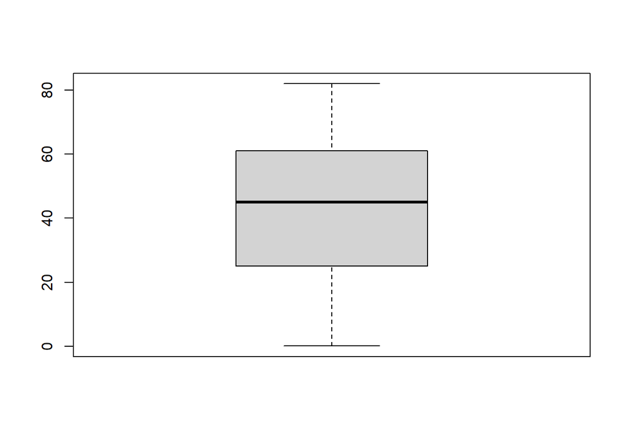

```r
 boxplot(brain_stroke$age)
```

**boxplot of avg_glucose_level**

boxplot to visualize the distribution of avg_glucose_level in our dataset, it includes the median, quartiles, and potential outliers of the avg_glucose_level variable.

```r
boxplot.stats(brain_stroke$avg_glucose_level)$out
```

```
##   [1] 228.69 171.23 174.12 186.21 214.09 191.61 221.29 193.94 233.29 228.70
##  [11] 208.30 195.23 212.08 196.92 252.72 219.72 213.03 243.58 196.71 194.99
##  [21] 180.93 185.17 221.58 179.12 228.56 240.09 226.98 235.63 240.59 190.32
##  [31] 231.61 191.82 216.94 259.63 249.31 200.59 190.14 182.99 206.09 263.32
##  [41] 207.28 194.37 199.20 221.79 239.07 223.83 231.56 221.89 195.71 203.87
##  [51] 185.49 213.22 215.94 205.77 271.74 200.62 242.52 175.29 208.65 205.33
##  [61] 210.40 219.73 250.89 205.35 216.58 184.40 199.84 218.46 211.06 197.28
##  [71] 233.94 247.51 243.53 198.21 206.72 214.45 190.70 203.04 242.30 220.49
##  [81] 218.46 216.70 234.58 235.85 243.50 182.20 229.92 215.60 239.64 200.28
##  [91] 205.23 210.78 251.60 213.37 223.36 178.29 203.81 205.26 211.03 225.47
## [101] 180.63 227.10 201.76 217.30 196.01 186.17 183.45 193.83 183.34 247.69
## [111] 191.47 239.82 189.57 207.58 182.86 215.64 196.36 205.50 204.86 228.08
## [121] 219.53 219.97 214.05 200.49 240.71 197.10 194.62 222.21 250.20 173.43
## [131] 184.25 254.60 212.01 186.45 189.49 186.32 194.04 237.15 231.19 207.32
## [141] 207.64 236.84 204.63 232.89 195.03 170.95 227.91 204.50 254.63 246.34
```

[output cut: 46 more lines]

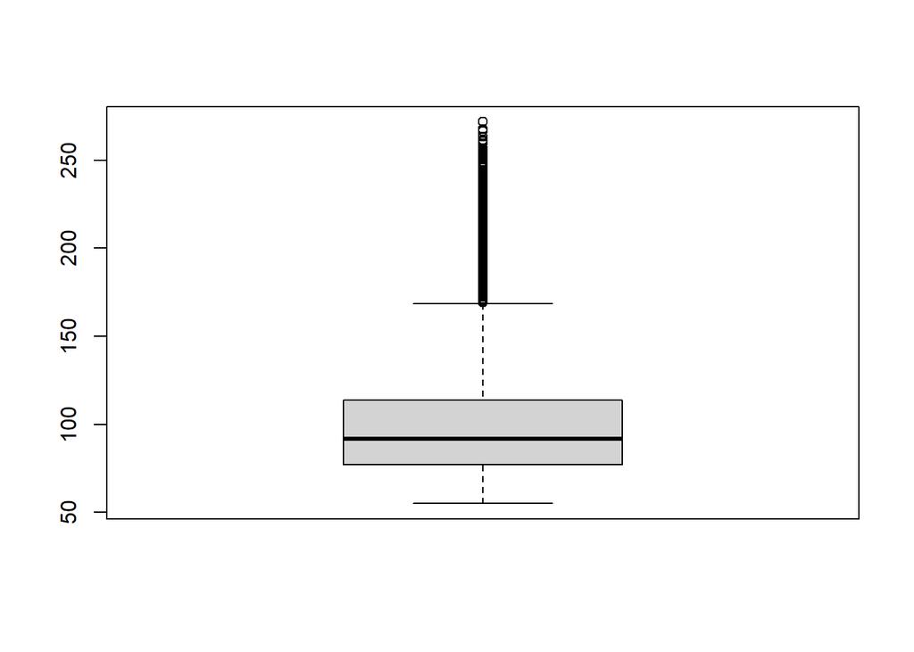

```r
boxplot(brain_stroke$avg_glucose_level)
```

**boxplot of bmi**

a boxplot to visualize the distribution of bmi in our dataset, it includes the median, quartiles, and potential outliers of the bmi variable.

```r
boxplot.stats(brain_stroke$bmi)$out
```

```
##  [1] 48.9 47.5 46.0 48.2 47.3 46.5 46.6 47.8 46.1 48.4 46.2 47.5 48.5 48.9 48.5
## [16] 48.7 48.9 46.5 48.8 46.0 48.0 46.8 48.3 48.3 47.4 47.3 47.9 46.2 46.1 46.0
## [31] 47.6 48.8 47.5 46.4 46.9 47.1 48.1 47.8 47.6 46.3 46.0 47.6 46.9
```

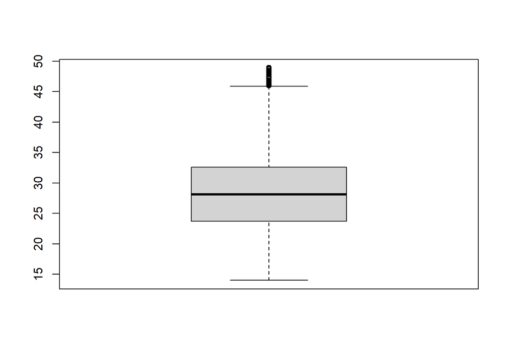

```r
boxplot(brain_stroke$bmi)
```

## **histogram**

**Shows Distribution of ages**

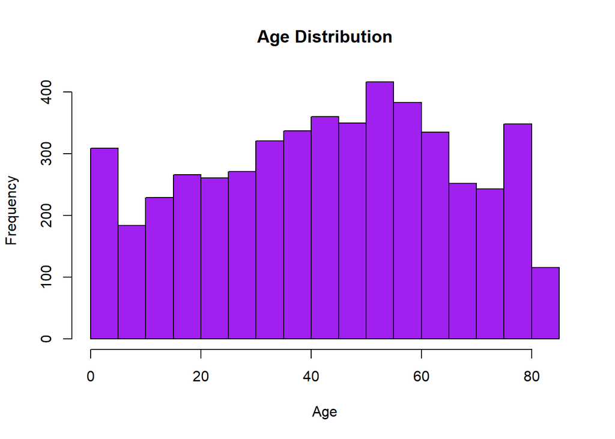

```r
hist(brain_stroke$age, col = "purple", main = "Age Distribution", xlab
= "Age")
```

## **Scatter plot**

**Shows the relationship between two attributes: “average glucose level” (on the x-axis) and “BMI” (Body Mass Index, on the y-axis)**

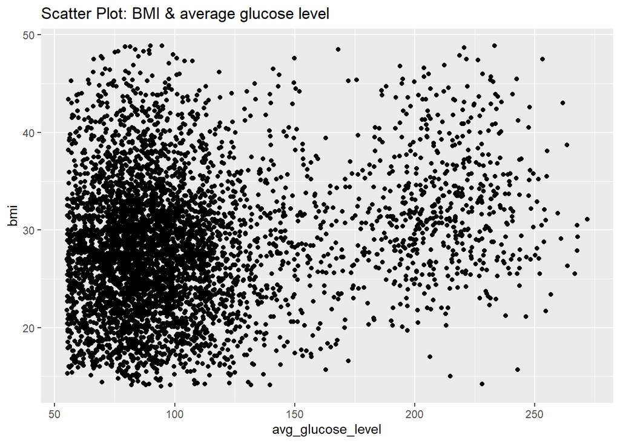

```r
ggplot(brain_stroke, aes(x = avg_glucose_level, y = bmi)) +
geom_point() + labs(title = "Scatter Plot: BMI & average glucose level")
```

```r
cor(brain_stroke$avg_glucose_level, brain_stroke$bmi)
```

```
## [1] 0.1863482
```

[1] 0.1863482 Based on the scatter plot and the correlation number We noticed that the correlation between the two attributes is very weak because the correlation is between 0 and 0.199.

## Pie charts

**Shows Distribution of Residence Types**

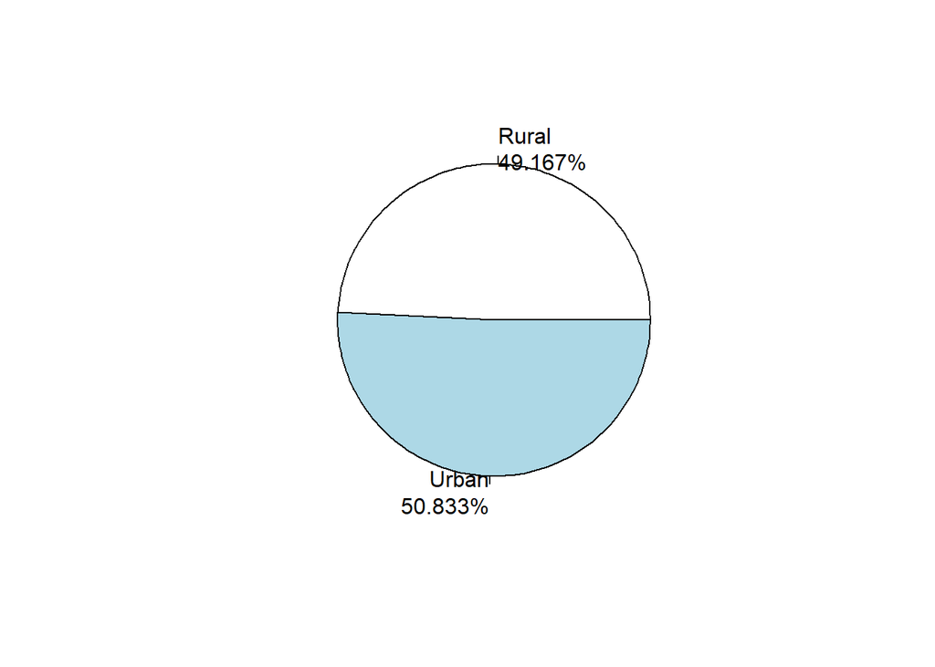

```r
tab <- table(brain_stroke$Residence_type)

percentages <- prop.table(tab) * 100

txt <- paste0(names(tab), '\n', round(percentages, 3), '%')

pie(tab, labels = txt)
```

We notice from this pie chart that the majority of people in this dataset live in urban residence

## **Bar Plots**

### 1 - Shows the disturbution of work type

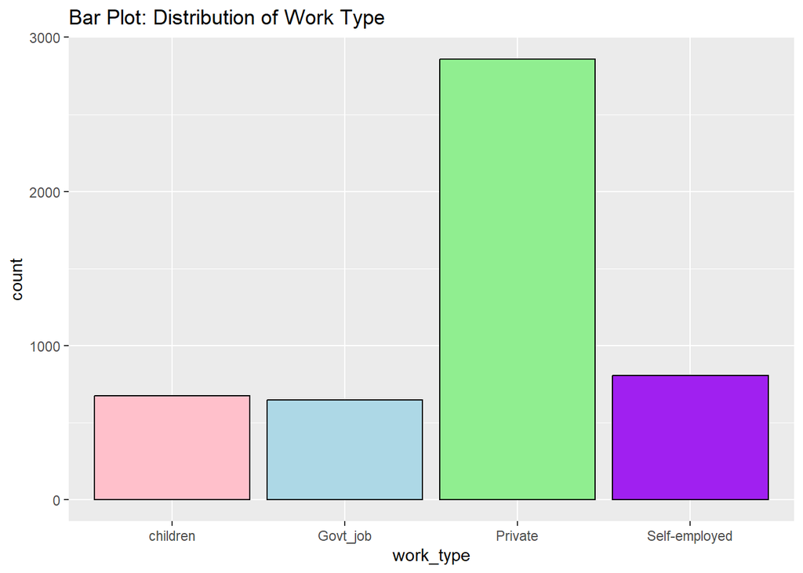

```r
library(ggplot2)

# Assuming you have a data frame named 'brain_stroke'

# Define a custom color palette
my_colors <- c("pink", "lightblue", "lightgreen", "purple")  # You can add more colors as needed

ggplot(brain_stroke, aes(x = work_type, fill = work_type)) +
  geom_bar(color = "black", fill = my_colors) +
  labs(title = "Bar Plot: Distribution of Work Type")
```

We notice from this bar plot that the majority of people in this dataset work for a private organization.

### 2 - The resulting plot visually shows the distribution of heart disease cases and their association with brain stroke.

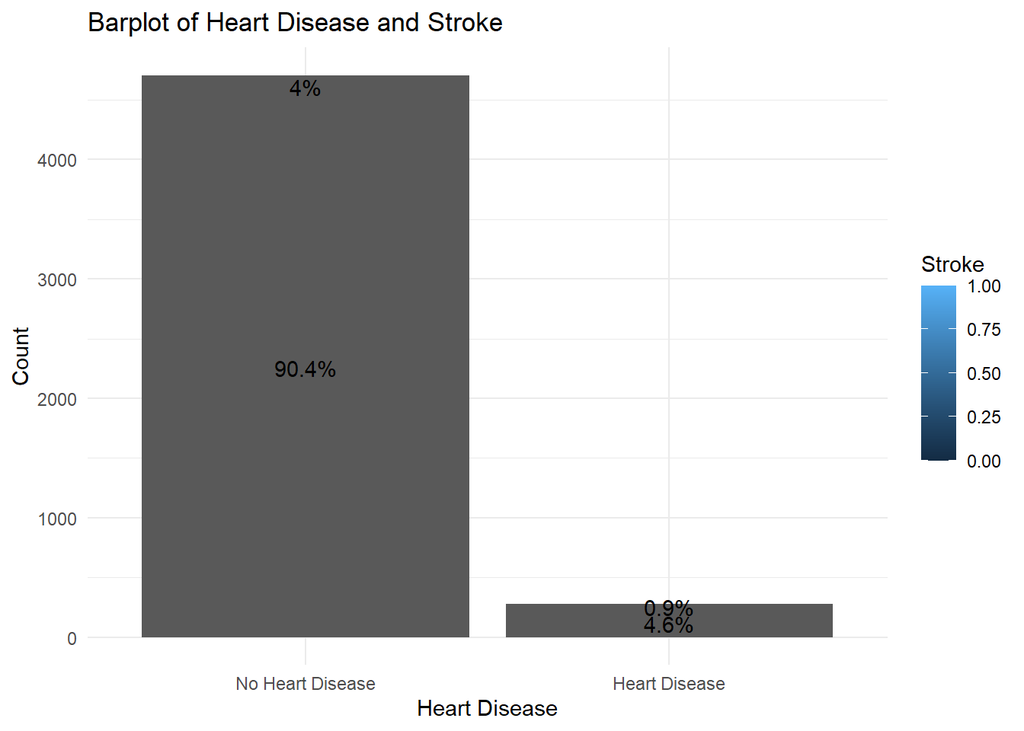

```r
library(ggplot2)
library(dplyr)

percentages <- brain_stroke %>%
  group_by(heart_disease, stroke) %>%
  summarize(count = n(), .groups = "drop") %>%
  mutate(percentage = (count / sum(count)) * 100)

ggplot(brain_stroke, aes(x = factor(heart_disease), fill = stroke)) +
  geom_bar() +
  geom_text(data = percentages, aes(label = paste0(round(percentage, 1), "%"), y = count),
            position = position_stack(vjust = 0.5)) +
  labs(x = "Heart Disease", y = "Count", fill = "Stroke") +
  scale_x_discrete(labels = c("No Heart Disease", "Heart Disease")) +
  ggtitle("Barplot of Heart Disease and Stroke") +
  theme_minimal()
```

The perecentage at the top of the column shows the percentage of having a brain stroke #We notice from this bar plot that people with heart disease have a higher risk of experiencing a brain stroke

### 3 - The resulting plot visually shows the distribution of hypertension cases and their association with brain stroke.

```r
percentages <- brain_stroke %>%
  group_by(hypertension, stroke) %>%
  summarize(count = n()) %>%
  mutate(percentage = (count / sum(count)) * 100)
```

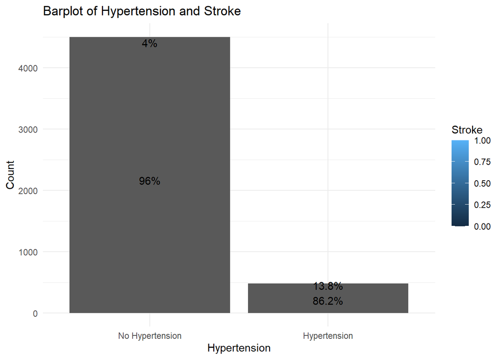

```r
ggplot(brain_stroke, aes(x = factor(hypertension), fill = stroke)) +
  geom_bar() +
  geom_text(data = percentages, aes(label = paste0(round(percentage, 1), "%"), y = count),
            position = position_stack(vjust = 0.5)) +
  labs(x = "Hypertension", y = "Count", fill = "Stroke") +
  ggtitle("Barplot of Hypertension and Stroke") +
  scale_x_discrete(labels = c("No Hypertension", "Hypertension")) +  # Custom labels
  theme_minimal()
```

The perecentage at the top of the column shows the percentage of having a brain stroke ,We notice from this bar plot that people with hypertension have a higher risk of experiencing a brain stroke.

### 4 - bar blot that shows the distrbutaion of smoking status.

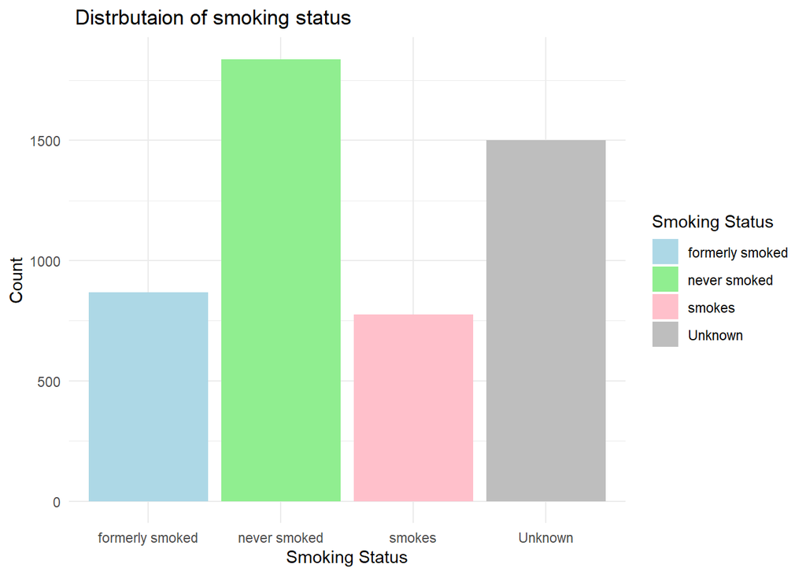

```r
library(ggplot2)

ggplot(brain_stroke) +
  geom_bar(aes(x = smoking_status, fill = smoking_status)) +
  labs(
    title = " Distrbutaion of smoking status",
    x = "Smoking Status",
    y = "Count",
    fill = "Smoking Status"
  ) +
  scale_fill_manual(values = c("formerly smoked" = "lightblue", "never smoked" = "lightgreen", "smokes" = "pink", "Unknown" = "gray")) +
  theme_minimal()
```

### 4 - bar blot that helps visualize if there is any association between smoking status and the likelihood of experiencing a stroke.(بينشال او الكومنت يتعدل)

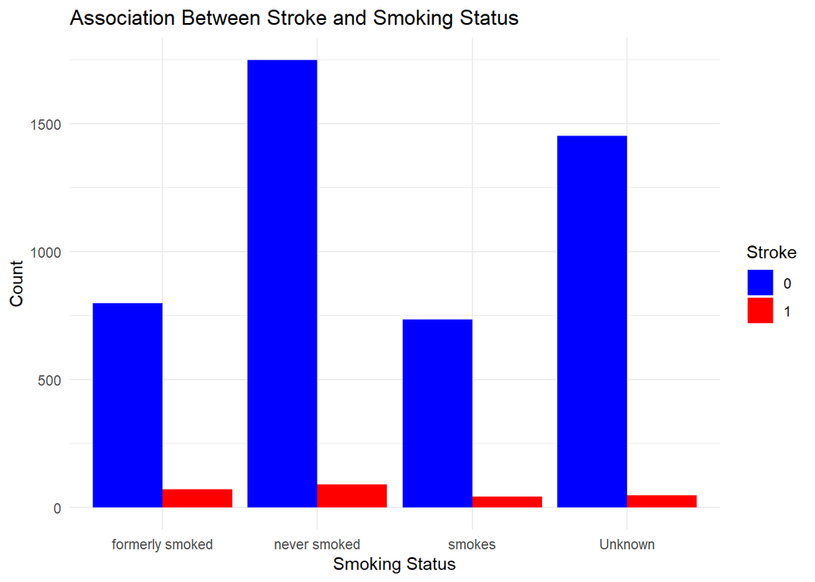

```r
library(ggplot2)

ggplot(brain_stroke) +
  geom_bar(mapping = aes(x = smoking_status, fill = factor(stroke)), position = "dodge") +
  labs(
    title = "Association Between Stroke and Smoking Status",
    x = "Smoking Status",
    y = "Count",
    fill = "Stroke"
  ) +
  scale_fill_manual(values = c("0" = "blue", "1" = "red")) +
  theme_minimal()
```

We notice from this bar plot that people who formerly smoked and smokes have a higher risk of experiencing a brain stroke, we notice that by comparing between the length of the blue columns which represnt each smoking staus not having a stroke posability against the length of the red column wich represent having stroke*

### 5- Class plot that shows if the dataset is balanced or imbalanced

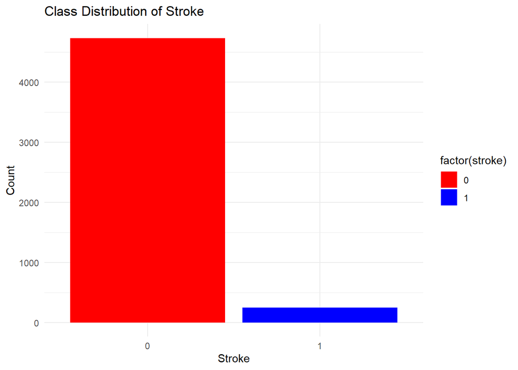

```r
library(ggplot2)

ggplot(brain_stroke, aes(x = factor(stroke), fill = factor(stroke))) +
  geom_bar() +
  labs(
    title = "Class Distribution of Stroke",
    x = "Stroke",
    y = "Count"
  ) +
  theme_minimal() +
  scale_fill_manual(values = c("0" = "red", "1" = "blue"))
```

This plot shows that our dataset is imbalanced, The “0” column (no stroke) is significantly higher than the “1” column (stroke), it indicates an imbalance in the dataset with respect to the stroke class.

# 4.Pre-Processing

## Outliers

```r
library(outliers)

Outavg_glucose_level = outlier(brain_stroke$avg_glucose_level, logical =TRUE)
sum(Outavg_glucose_level)
```

```
## [1] 1
```

```r
Find_outlier = which(Outavg_glucose_level ==TRUE, arr.ind = TRUE)
Outavg_glucose_level
```

```
##    [1] FALSE FALSE FALSE FALSE FALSE FALSE FALSE FALSE FALSE FALSE FALSE FALSE
##   [13] FALSE FALSE FALSE FALSE FALSE FALSE FALSE FALSE FALSE FALSE FALSE FALSE
##   [25] FALSE FALSE FALSE FALSE FALSE FALSE FALSE FALSE FALSE FALSE FALSE FALSE
##   [37] FALSE FALSE FALSE FALSE FALSE FALSE FALSE FALSE FALSE FALSE FALSE FALSE
##   [49] FALSE FALSE FALSE FALSE FALSE FALSE FALSE FALSE FALSE FALSE FALSE FALSE
##   [61] FALSE FALSE FALSE FALSE FALSE FALSE FALSE FALSE FALSE FALSE FALSE FALSE
##   [73] FALSE FALSE FALSE FALSE FALSE FALSE FALSE FALSE FALSE FALSE FALSE FALSE
##   [85] FALSE FALSE FALSE FALSE FALSE FALSE FALSE FALSE FALSE FALSE FALSE FALSE
##   [97] FALSE FALSE FALSE FALSE FALSE FALSE FALSE FALSE FALSE FALSE FALSE FALSE
##  [109] FALSE FALSE FALSE FALSE FALSE FALSE FALSE FALSE FALSE FALSE FALSE FALSE
##  [121] FALSE FALSE FALSE FALSE FALSE FALSE FALSE FALSE FALSE FALSE FALSE FALSE
##  [133] FALSE FALSE FALSE FALSE FALSE FALSE FALSE FALSE FALSE FALSE FALSE FALSE
##  [145] FALSE FALSE FALSE FALSE FALSE FALSE FALSE FALSE FALSE FALSE FALSE FALSE
##  [157] FALSE  TRUE FALSE FALSE FALSE FALSE FALSE FALSE FALSE FALSE FALSE FALSE
##  [169] FALSE FALSE FALSE FALSE FALSE FALSE FALSE FALSE FALSE FALSE FALSE FALSE
```

[output cut: 401 more lines]

```r
Find_outlier
```

```
## [1] 158
```

```r
Outbmi = outlier(brain_stroke$bmi, logical =TRUE)
sum(Outbmi)
```

```
## [1] 3
```

```r
Find_outlier = which(Outbmi ==TRUE, arr.ind = TRUE)
Outbmi
```

```
##    [1] FALSE FALSE FALSE FALSE FALSE FALSE FALSE FALSE FALSE FALSE FALSE FALSE
##   [13] FALSE FALSE FALSE FALSE FALSE  TRUE FALSE FALSE FALSE FALSE FALSE FALSE
##   [25] FALSE FALSE FALSE FALSE FALSE FALSE FALSE FALSE FALSE FALSE FALSE FALSE
##   [37] FALSE FALSE FALSE FALSE FALSE FALSE FALSE FALSE FALSE FALSE FALSE FALSE
##   [49] FALSE FALSE FALSE FALSE FALSE FALSE FALSE FALSE FALSE FALSE FALSE FALSE
##   [61] FALSE FALSE FALSE FALSE FALSE FALSE FALSE FALSE FALSE FALSE FALSE FALSE
##   [73] FALSE FALSE FALSE FALSE FALSE FALSE FALSE FALSE FALSE FALSE FALSE FALSE
##   [85] FALSE FALSE FALSE FALSE FALSE FALSE FALSE FALSE FALSE FALSE FALSE FALSE
##   [97] FALSE FALSE FALSE FALSE FALSE FALSE FALSE FALSE FALSE FALSE FALSE FALSE
##  [109] FALSE FALSE FALSE FALSE FALSE FALSE FALSE FALSE FALSE FALSE FALSE FALSE
##  [121] FALSE FALSE FALSE FALSE FALSE FALSE FALSE FALSE FALSE FALSE FALSE FALSE
##  [133] FALSE FALSE FALSE FALSE FALSE FALSE FALSE FALSE FALSE FALSE FALSE FALSE
##  [145] FALSE FALSE FALSE FALSE FALSE FALSE FALSE FALSE FALSE FALSE FALSE FALSE
##  [157] FALSE FALSE FALSE FALSE FALSE FALSE FALSE FALSE FALSE FALSE FALSE FALSE
##  [169] FALSE FALSE FALSE FALSE FALSE FALSE FALSE FALSE FALSE FALSE FALSE FALSE
```

[output cut: 401 more lines]

```r
Find_outlier
```

```
## [1]   18 1834 2136
```

```r
Outage = outlier(brain_stroke$age, logical =TRUE)
sum(Outage)
```

```
## [1] 2
```

```r
Find_outlier = which(Outage ==TRUE, arr.ind = TRUE)
Outage
```

```
##    [1] FALSE FALSE FALSE FALSE FALSE FALSE FALSE FALSE FALSE FALSE FALSE FALSE
##   [13] FALSE FALSE FALSE FALSE FALSE FALSE FALSE FALSE FALSE FALSE FALSE FALSE
##   [25] FALSE FALSE FALSE FALSE FALSE FALSE FALSE FALSE FALSE FALSE FALSE FALSE
##   [37] FALSE FALSE FALSE FALSE FALSE FALSE FALSE FALSE FALSE FALSE FALSE FALSE
##   [49] FALSE FALSE FALSE FALSE FALSE FALSE FALSE FALSE FALSE FALSE FALSE FALSE
##   [61] FALSE FALSE FALSE FALSE FALSE FALSE FALSE FALSE FALSE FALSE FALSE FALSE
##   [73] FALSE FALSE FALSE FALSE FALSE FALSE FALSE FALSE FALSE FALSE FALSE FALSE
##   [85] FALSE FALSE FALSE FALSE FALSE FALSE FALSE FALSE FALSE FALSE FALSE FALSE
##   [97] FALSE FALSE FALSE FALSE FALSE FALSE FALSE FALSE FALSE FALSE FALSE FALSE
##  [109] FALSE FALSE FALSE FALSE FALSE FALSE FALSE FALSE FALSE FALSE FALSE FALSE
##  [121] FALSE FALSE FALSE FALSE FALSE FALSE FALSE FALSE FALSE FALSE FALSE FALSE
##  [133] FALSE FALSE FALSE FALSE FALSE FALSE FALSE FALSE FALSE FALSE FALSE FALSE
##  [145] FALSE FALSE FALSE FALSE FALSE FALSE FALSE FALSE FALSE FALSE FALSE FALSE
##  [157] FALSE FALSE FALSE FALSE FALSE FALSE FALSE FALSE FALSE FALSE FALSE FALSE
##  [169] FALSE FALSE FALSE FALSE FALSE FALSE FALSE FALSE FALSE FALSE FALSE FALSE
```

[output cut: 401 more lines]

```r
Find_outlier
```

```
## [1] 1488 3058
```

## Normalization

```r
normalize <- function(x) {return ((x - min(x)) / (max(x) - min(x)))}
dataWithoutNormalization <- brain_stroke
brain_stroke$bmi<-normalize(dataWithoutNormalization$bmi)
brain_stroke$age<-normalize(dataWithoutNormalization$age)
brain_stroke$avg_glucose_level<-normalize(dataWithoutNormalization$age)
print(brain_stroke)
```

```
## # A tibble: 4,981 × 11
##    gender   age hypertension heart_disease ever_married work_type Residence_type
##    <chr>  <dbl>        <dbl>         <dbl> <chr>        <chr>     <chr>
##  1 Male   0.817            0             1 Yes          Private   Urban
##  2 Male   0.976            0             1 Yes          Private   Rural
##  3 Female 0.597            0             0 Yes          Private   Urban
##  4 Female 0.963            1             0 Yes          Self-emp… Rural
##  5 Male   0.988            0             0 Yes          Private   Urban
##  6 Male   0.902            1             1 Yes          Private   Rural
##  7 Female 0.841            0             0 No           Private   Urban
##  8 Female 0.951            0             0 Yes          Private   Urban
##  9 Female 0.988            1             0 Yes          Private   Rural
## 10 Female 0.744            0             1 Yes          Govt_job  Rural
## # ℹ 4,971 more rows
## # ℹ 4 more variables: avg_glucose_level <dbl>, bmi <dbl>, smoking_status <chr>,
## #   stroke <dbl>
```

## Discretization

```r
#we do not need feature discretization because the data is already well-preprocessed.
```

## Feature selection

### correlation

```r
#feature selection - correlation analysis (numric)
cor(brain_stroke$age, brain_stroke$stroke)
```

```
## [1] 0.2464779
```

```r
cor(brain_stroke$bmi, brain_stroke$stroke)
```

```
## [1] 0.05692566
```

```r
cor(brain_stroke$hypertension, brain_stroke$stroke)
```

```
## [1] 0.1319652
```

```r
cor(brain_stroke$heart_disease, brain_stroke$stroke)
```

```
## [1] 0.1346103
```

```r
cor(brain_stroke$avg_glucose_level, brain_stroke$stroke)
```

```
## [1] 0.2464779
```

There’s a weak correlations between numerical attributes (typically below 0.3) . This implies that feature selection isn’t necessary.

### Chi square

```r
#feature selection - chi square (cateorigal)

chi_squared_result <-
chisq.test(table(brain_stroke$gender, brain_stroke$stroke))
print(chi_squared_result)
```

```
##
##  Pearson's Chi-squared test with Yates' continuity correction
##
## data:  table(brain_stroke$gender, brain_stroke$stroke)
## X-squared = 0.31352, df = 1, p-value = 0.5755
```

```r
chi_squared_result <-
chisq.test(table(brain_stroke$work_type, brain_stroke$stroke))
print(chi_squared_result)
```

```
##
##  Pearson's Chi-squared test
##
## data:  table(brain_stroke$work_type, brain_stroke$stroke)
## X-squared = 47.832, df = 3, p-value = 2.312e-10
```

```r
chi_squared_result <-
chisq.test(table(brain_stroke$Residence_type, brain_stroke$stroke))
print(chi_squared_result)
```

```
##
##  Pearson's Chi-squared test with Yates' continuity correction
##
## data:  table(brain_stroke$Residence_type, brain_stroke$stroke)
## X-squared = 1.2077, df = 1, p-value = 0.2718
```

```r
chi_squared_result <-
chisq.test(table(brain_stroke$smoking_status, brain_stroke$stroke))
print(chi_squared_result)
```

```
##
##  Pearson's Chi-squared test
##
## data:  table(brain_stroke$smoking_status, brain_stroke$stroke)
## X-squared = 28.734, df = 3, p-value = 2.548e-06
```

```r
chi_squared_result <-
chisq.test(table(brain_stroke$ever_married, brain_stroke$stroke))
print(chi_squared_result)
```

```
##
##  Pearson's Chi-squared test with Yates' continuity correction
##
## data:  table(brain_stroke$ever_married, brain_stroke$stroke)
## X-squared = 57.481, df = 1, p-value = 3.412e-14
```

After each test, the result is used to display the chi-squared test result, including the chi-squared statistic, degrees of freedom, by comparing chi-square value with the DF in the probability level table, it showed that the attributs “work_type”, “smoking_status”, “ever_married” have a greater chi square value than DF value.

### Encoding and scaling

#### Data types should be transformed into numeric types before clustering.

### Encoding

```r
#Encoding

brain_stroke$work_type = factor(brain_stroke$work_type,levels = c("Govt_job","Private", "Self-employed"
,"children","Never_worked"), labels = c(5,4,3,2,1))

brain_stroke$gender = factor(brain_stroke$gender, levels = c("Male", "Female"), labels = c(1, 2))

brain_stroke$ever_married= factor(brain_stroke$ever_married, levels = c("No", "Yes"), labels = c(0, 1))

brain_stroke$Residence_type = factor(brain_stroke$Residence_type, levels = c("Urban", "Rural"), labels = c(1, 2))


brain_stroke$smoking_status = factor(brain_stroke$smoking_status, levels = c("Unknown", "never smoked", "formerly smoked", "smokes"), labels = c(1, 2, 3, 4))


#encoding الي ضبط الاكواد

brain_stroke$gender <- as.numeric(brain_stroke$gender)
brain_stroke$ever_married <- as.numeric(brain_stroke$ever_married)
brain_stroke$work_type <- as.numeric(brain_stroke$work_type)
brain_stroke$Residence_type <- as.numeric(brain_stroke$Residence_type)
brain_stroke$smoking_status <- as.numeric(brain_stroke$smoking_status)
```

```r
View(brain_stroke)
data("brain_stroke")
summary(brain_stroke)
```

```
##      gender           age          hypertension     heart_disease
##  Min.   :1.000   Min.   :0.0000   Min.   :0.00000   Min.   :0.00000
##  1st Qu.:1.000   1st Qu.:0.3042   1st Qu.:0.00000   1st Qu.:0.00000
##  Median :2.000   Median :0.5483   Median :0.00000   Median :0.00000
##  Mean   :1.584   Mean   :0.5291   Mean   :0.09617   Mean   :0.05521
##  3rd Qu.:2.000   3rd Qu.:0.7437   3rd Qu.:0.00000   3rd Qu.:0.00000
##  Max.   :2.000   Max.   :1.0000   Max.   :1.00000   Max.   :1.00000
##   ever_married     work_type     Residence_type  avg_glucose_level
##  Min.   :1.000   Min.   :1.000   Min.   :1.000   Min.   :0.0000
##  1st Qu.:1.000   1st Qu.:2.000   1st Qu.:1.000   1st Qu.:0.3042
##  Median :2.000   Median :2.000   Median :1.000   Median :0.5483
##  Mean   :1.659   Mean   :2.302   Mean   :1.492   Mean   :0.5291
##  3rd Qu.:2.000   3rd Qu.:3.000   3rd Qu.:2.000   3rd Qu.:0.7437
##  Max.   :2.000   Max.   :4.000   Max.   :2.000   Max.   :1.0000
##       bmi         smoking_status      stroke
##  Min.   :0.0000   Min.   :1.000   Min.   :0.00000
##  1st Qu.:0.2779   1st Qu.:1.000   1st Qu.:0.00000
##  Median :0.4040   Median :2.000   Median :0.00000
##  Mean   :0.4154   Mean   :2.185   Mean   :0.04979
##  3rd Qu.:0.5330   3rd Qu.:3.000   3rd Qu.:0.00000
##  Max.   :1.0000   Max.   :4.000   Max.   :1.00000
```

```r
str(brain_stroke)
```

```
## spc_tbl_ [4,981 × 11] (S3: spec_tbl_df/tbl_df/tbl/data.frame)
##  $ gender           : num [1:4981] 1 1 2 2 1 1 2 2 2 2 ...
##  $ age              : num [1:4981] 0.817 0.976 0.597 0.963 0.988 ...
##  $ hypertension     : num [1:4981] 0 0 0 1 0 1 0 0 1 0 ...
##  $ heart_disease    : num [1:4981] 1 1 0 0 0 1 0 0 0 1 ...
##  $ ever_married     : num [1:4981] 2 2 2 2 2 2 1 2 2 2 ...
##  $ work_type        : num [1:4981] 2 2 2 3 2 2 2 2 2 1 ...
##  $ Residence_type   : num [1:4981] 1 2 1 2 1 2 1 1 2 2 ...
##  $ avg_glucose_level: num [1:4981] 0.817 0.976 0.597 0.963 0.988 ...
##  $ bmi              : num [1:4981] 0.648 0.53 0.585 0.287 0.43 ...
##  $ smoking_status   : num [1:4981] 3 2 4 2 3 2 2 1 2 4 ...
##  $ stroke           : num [1:4981] 1 1 1 1 1 1 1 1 1 1 ...
##  - attr(*, "spec")=
##   .. cols(
##   ..   gender = col_character(),
##   ..   age = col_double(),
##   ..   hypertension = col_double(),
##   ..   heart_disease = col_double(),
##   ..   ever_married = col_character(),
##   ..   work_type = col_character(),
##   ..   Residence_type = col_character(),
##   ..   avg_glucose_level = col_double(),
##   ..   bmi = col_double(),
##   ..   smoking_status = col_character(),
##   ..   stroke = col_double()
##   .. )
##  - attr(*, "problems")=<externalptr>
```

### Scale

```r
# Define the columns you want to scale
columns_to_scale <- c("age", "avg_glucose_level", "bmi")


brain_stroke[columns_to_scale] <- scale(brain_stroke[columns_to_scale])
View(brain_stroke)
```

```r
### load the data after preprocessing to a CVS file

write.csv(brain_stroke, file = "dataset_brain_stroke.csv" ,row.names = FALSE)
### load the processed data

datasetbrainstroke <- read.csv("dataset_brain_stroke.csv" ,header = TRUE,sep=',', stringsAsFactors = T)
```

# 5. Data mining Technique

**classification packages:**

Building a Decision Tree Model using the Gini Index: We employed the (rpart) package to construct a decision tree model. This package is widely used for splitting or dividing data and it includes features for generating and showcasing decision trees. It specifically employs the CART (Classification and Regression Trees) algorithm to structure and present the data in a tree-like format.

## Clustering

Clustering is an unsupervised machine learning technique used to discover inherent patterns and structures within datasets. Unlike supervised methods, clustering works on unlabeled data, grouping similar instances together based on feature similarities. This exploration technique is valuable for various applications, including data segmentation and anomaly detection.

In this analysis, we will apply clustering algorithms to a dataset related to brain stroke prediction. By identifying natural groupings within the data, we aim to uncover insights into potential risk factors associated with stroke occurrences.

We will conduct a cluster analysis using three different values for k in order to determine the optimal number of clusters. These three k values are selected based on the elbow method, which indicates that k=4 is a potentially optimal number of clusters. Therefore, we will also explore k=3 and k=2 alongside k=4 to assess the clustering performance.

### Removing class label before clustering

#### Because Clustering is a form of unsupervised learning, which means the algorithm doesn’t use any prior knowledge of class labels or target values. Instead, it discovers patterns or structures within the data based on the features provided.

```r
brain_stroke <- subset(brain_stroke, select = -stroke)

head(brain_stroke)
```

| gender | age | hypertension | heart_disease | ever_married | work_type | Residence_type | avg_glucose_level | bmi | smoking_status |
| --- | --- | --- | --- | --- | --- | --- | --- | --- | --- |
| 1 | 1.0404799 | 0 | 1 | 2 | 2 | 1 | 1.0404799 | 1.19311838 | 3 |
| 1 | 1.6141083 | 0 | 1 | 2 | 2 | 2 | 1.6141083 | 0.58933044 | 2 |
| 2 | 0.2462252 | 0 | 0 | 2 | 2 | 1 | 0.2462252 | 0.86913461 | 4 |
| 2 | 1.5699830 | 1 | 0 | 2 | 3 | 2 | 1.5699830 | -0.66242503 | 2 |
| 1 | 1.6582335 | 0 | 0 | 2 | 2 | 1 | 1.6582335 | 0.07390172 | 3 |
| 1 | 1.3493567 | 1 | 1 | 2 | 2 | 2 | 1.3493567 | -0.16172284 | 2 |

[output not shown]

6 rows | 1-7 of 10 columns

### K-means clustering, K= 2 Clusters

```r
# run k-means clustering to find 2 clusters
#set a seed for random number generation  to make the results reproducible
set.seed(8953)
kmeans.result <- kmeans(brain_stroke, 2)
# print the clusterng result
kmeans.result
```

```
## K-means clustering with 2 clusters of sizes 1364, 3617
##
## Cluster means:
##     gender        age hypertension heart_disease ever_married work_type
## 1 1.558651 -1.2566437  0.002199413  0.0007331378     1.098240  3.006598
## 2 1.593033  0.4738905  0.131600774  0.0757533868     1.869782  2.036771
##   Residence_type avg_glucose_level       bmi smoking_status
## 1       1.499267        -1.2566437 -0.839327       1.442082
## 2       1.488803         0.4738905  0.316517       2.464473
##
## Clustering vector:
##    [1] 2 2 2 2 2 2 2 2 2 2 2 2 2 2 2 2 2 2 2 2 2 2 2 2 2 2 2 2 2 2 2 2 2 2 2 2 2
##   [38] 2 2 2 2 2 2 2 2 2 2 2 2 2 2 2 2 2 2 2 2 2 2 2 2 2 2 2 2 2 2 2 2 2 2 2 2 2
##   [75] 2 2 2 2 2 2 2 2 2 2 2 2 2 2 2 2 2 2 2 2 2 2 2 2 2 2 2 2 2 2 2 2 2 2 2 2 2
##  [112] 2 2 2 2 2 2 2 2 2 2 2 2 2 2 2 2 2 2 2 2 2 2 2 2 2 2 2 2 2 2 2 2 2 2 2 2 2
```

[output cut: 140 more lines]

Results of a k-means clustering analysis on brain stroke , revealing two distinct clusters (Cluster 1 and Cluster 2). The cluster means highlight the average characteristics of each group, while the clustering vector assigns each individual to a specific cluster. The within-cluster sum of squares indicates the tightness of data points within each cluster, with Cluster 1 showing lower dispersion than Cluster 2.

### total within-cluster-sum of square

```r
#total within-cluster-sum of square
twss <- sum(kmeans.result$withinss)
print(twss)
```

```
## [1] 18358.56
```

The total within-cluster sum of squares (WSS) for 2 clusters is 18358.56. This metric reflects the sum of squared distances between data points and their assigned cluster centroids. In the context of the elbow method, this value provides an indication of the compactness of clusters. A higher WSS suggests less compact clusters, as points within each cluster are more dispersed.

#### Visualize clustering (2 clusters)

```r
# visualize clustering (2 clusters)
options(repos = c(CRAN = "https://cran.rstudio.com"))
install.packages("factoextra")
library(factoextra)
```

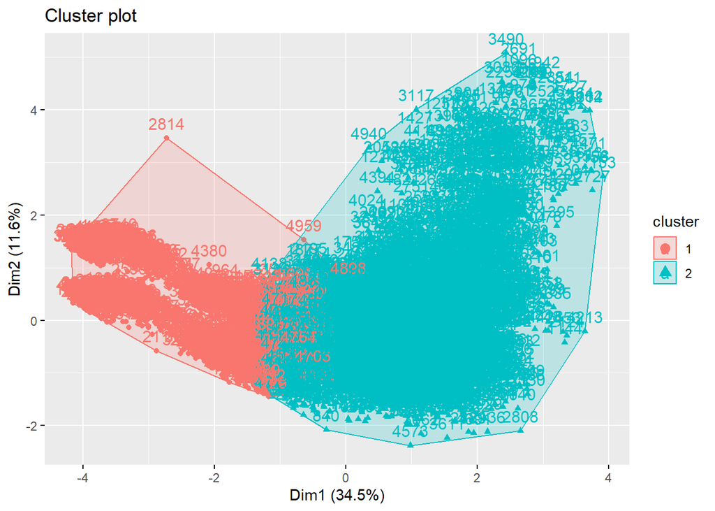

```r
fviz_cluster(kmeans.result, data = brain_stroke)
```

#### Another visualization (2 clusters)

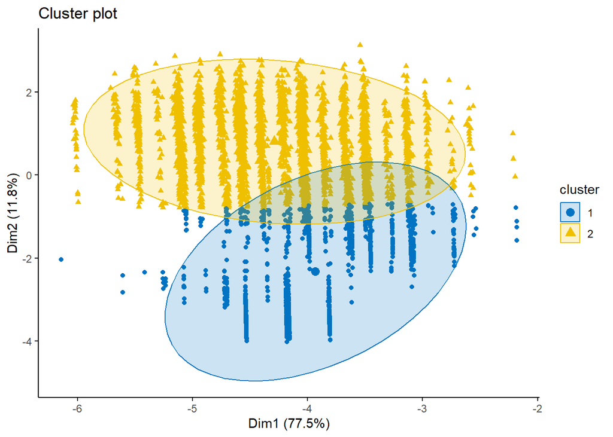

```r
library(factoextra)
fviz_cluster(list(data = brain_stroke, cluster = kmeans.result$cluster),
             ellipse.type = "norm", geom = "point", stand = FALSE,
             palette = "jco", ggtheme = theme_classic())
```

the first cluster has total sum of squares of 4136.747, while the second cluster has total sum of squares of 14221.813. The higher total sum of squares in the second cluster suggests a larger separation, indicating that the objects in the second cluster are more dispersed or separated compared to those in the first cluster.

#### Average silhouette for each clusters (2 clusters)

```
##   cluster size ave.sil.width
## 1       1 1364          0.39
## 2       2 3617          0.30
```

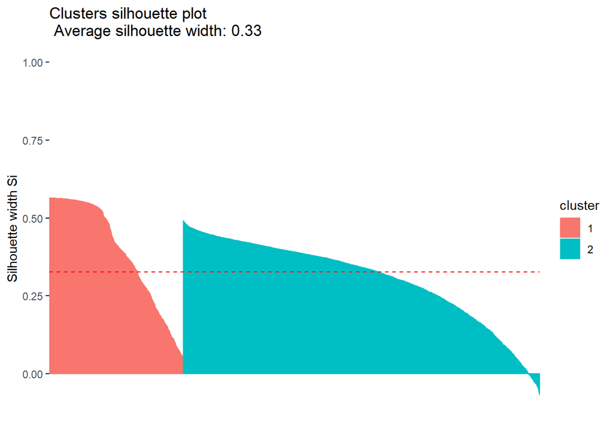

```r
library(cluster)
avg_sil <- silhouette(kmeans.result$cluster,dist(brain_stroke)) #a dissimilarity object inheriting from class dist or coercible to one. If not specified, dmatrix must be.
fviz_silhouette(avg_sil)#k-means clustering with estimating k and initializations
```

The silhouette plot displays silhouette values for each data point in the dataset. Silhouette values measure how similar an object is to its own cluster (cohesion) compared to other clusters (separation). Silhouette values range from -1 to 1, where a high value indicates that the object is well matched to its own cluster and poorly matched to neighboring clusters, This plot shows a moderate value where the avarege sillhoutte for 2 clusters = 0.33.

#### BCubed when cluster size=2

```r
cluster_assignments <- c(kmeans.result$cluster)
ground_truth_labels <- c(datasetbrainstroke$stroke)

if (length(cluster_assignments) > length(ground_truth_labels)) {
  cluster_assignments <- cluster_assignments[1:length(ground_truth_labels)]
} else if (length(cluster_assignments) < length(ground_truth_labels)) {
  ground_truth_labels <- ground_truth_labels[1:length(cluster_assignments)]
}

data <- data.frame(cluster = cluster_assignments, label = ground_truth_labels)

# Function to calculate BCubed precision and recall
calculate_bcubed_metrics <- function(data) {
  n <- nrow(data)
  precision_sum <- 0
  recall_sum <- 0

  for (i in 1:n) {
    cluster <- data$cluster[i]
    label <- data$label[i]

# Count the number of items from the same category within the same cluster
same_category_same_cluster <- sum(data$label[data$cluster == cluster] == label)

# Count the total number of items in the same cluster
total_same_cluster <- sum(data$cluster == cluster)

# Count the total number of items with the same category
total_same_category <- sum(data$label == label)

# Calculate precision and recall for the current item and add them to the sums
precision_sum <- precision_sum + same_category_same_cluster /total_same_cluster
recall_sum <- recall_sum + same_category_same_cluster / total_same_category
  }

  # Calculate average precision and recall
  precision <- precision_sum / n
  recall <- recall_sum / n

  return(list(precision = precision, recall = recall))
}

# Calculate BCubed precision and recall
metrics <- calculate_bcubed_metrics(data)

# Extract precision and recall from the metrics
precision <- metrics$precision
recall <- metrics$recall

# Print the results
cat("BCubed Precision:", precision, "\n")
```

```
## BCubed Precision: 0.9071407
```

```r
cat("BCubed Recall:", recall, "\n")
```

```
## BCubed Recall: 0.6096986
```

The BCubed precision at 0.907 reflects the model’s high accuracy in assigning items to clusters and, the lower recall of 0.610 implies a tendency to miss some items relevant to these clusters.

### K-means clustering, K= 3 Clusters

```r
# run k-means clustering to find 3 clusters
#set a seed for random number generation  to make the results reproducible
set.seed(8953)
kmeans.result <- kmeans(brain_stroke, 3)
# print the clusterng result
kmeans.result
```

```
## K-means clustering with 3 clusters of sizes 701, 1972, 2308
##
## Cluster means:
##     gender        age hypertension heart_disease ever_married work_type
## 1 1.470756 -1.5926010   0.00000000   0.001426534     1.000000  3.934379
## 2 1.644523 -0.4815955   0.02890467   0.004563895     1.576065  1.935091
## 3 1.565858  0.8951992   0.18284229   0.114818024     1.928943  2.120451
##   Residence_type avg_glucose_level        bmi smoking_status
## 1       1.502140        -1.5926010 -1.2328524       1.126961
## 2       1.503550        -0.4815955  0.0644400       2.229209
## 3       1.478336         0.8951992  0.3193908       2.467504
##
## Clustering vector:
##    [1] 3 3 3 3 3 3 3 3 3 3 3 3 3 3 3 3 3 3 3 3 3 3 3 3 3 2 3 3 2 3 3 3 3 3 3 3 3
##   [38] 3 3 3 3 2 3 3 3 3 3 3 3 3 3 2 3 3 3 3 3 3 3 3 3 3 3 3 2 3 3 3 3 3 3 3 3 3
```

[output cut: 142 more lines]

This k-means clustering result with three clusters reveals distinct patterns within the dataset. The clusters, with sizes 701, 1972, and 2308, exhibit characteristic feature means for various attributes.

### total within-cluster-sum of square

```r
#total within-cluster-sum of square
twss <- sum(kmeans.result$withinss)
print(twss)
```

```
## [1] 14981.07
```

The total within-cluster sum of squares (WSS) for 3 clusters is 14981.07. This metric gauges the sum of squared distances between data points and their assigned cluster centroids. In the context of the elbow method, the WSS is a criterion for evaluating the goodness of clustering. A lower WSS indicates more compact and cohesive clusters.

#### Visualize clustering (3 clusters)

```r
# visualize clustering (3 clusters)
install.packages("factoextra")
```

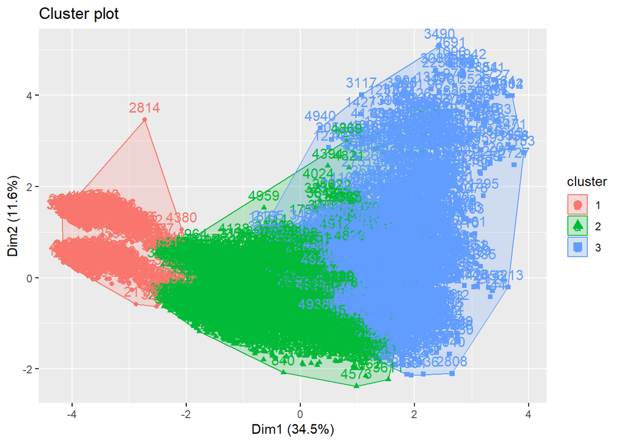

```r
library(factoextra)
fviz_cluster(kmeans.result, data = brain_stroke)
```

#### Another visualization (3 clusters)

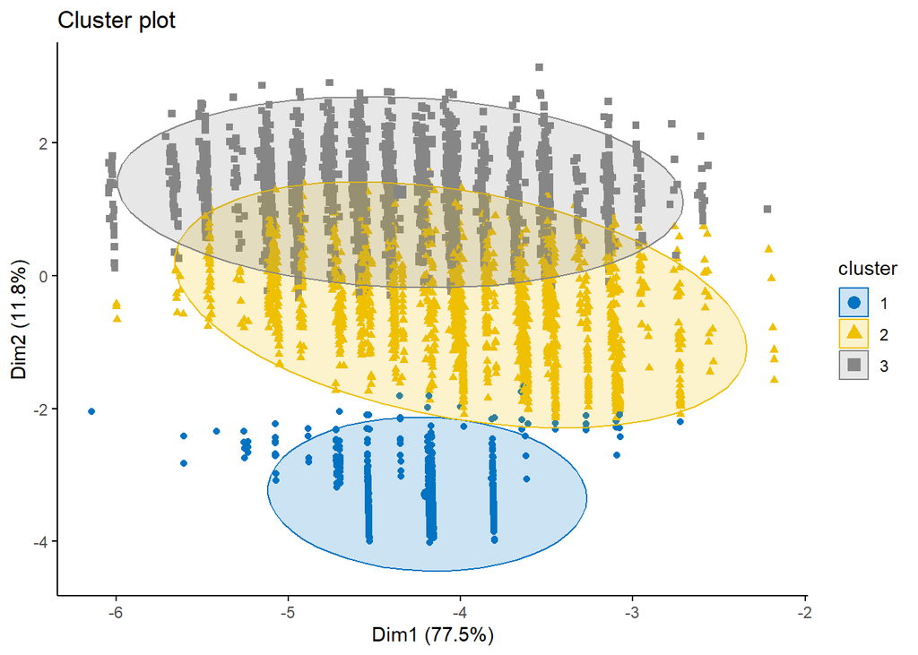

```r
library(factoextra)
fviz_cluster(list(data = brain_stroke, cluster = kmeans.result$cluster),
             ellipse.type = "norm", geom = "point", stand = FALSE,
             palette = "jco", ggtheme = theme_classic())
```

the first cluster has total sum of squares of 875.8454, while the second cluster has total sum of squares of 6393.1969, and the third has total sum of squares of 7712.0325. The higher total sum of squares in the third cluster suggests a larger separation, indicating that the objects in the third cluster are more dispersed or separated compared to other clusters.

#### Average silhouette for each clusters (3 clusters)

```
##   cluster size ave.sil.width
## 1       1  701          0.60
## 2       2 1972          0.17
## 3       3 2308          0.20
```

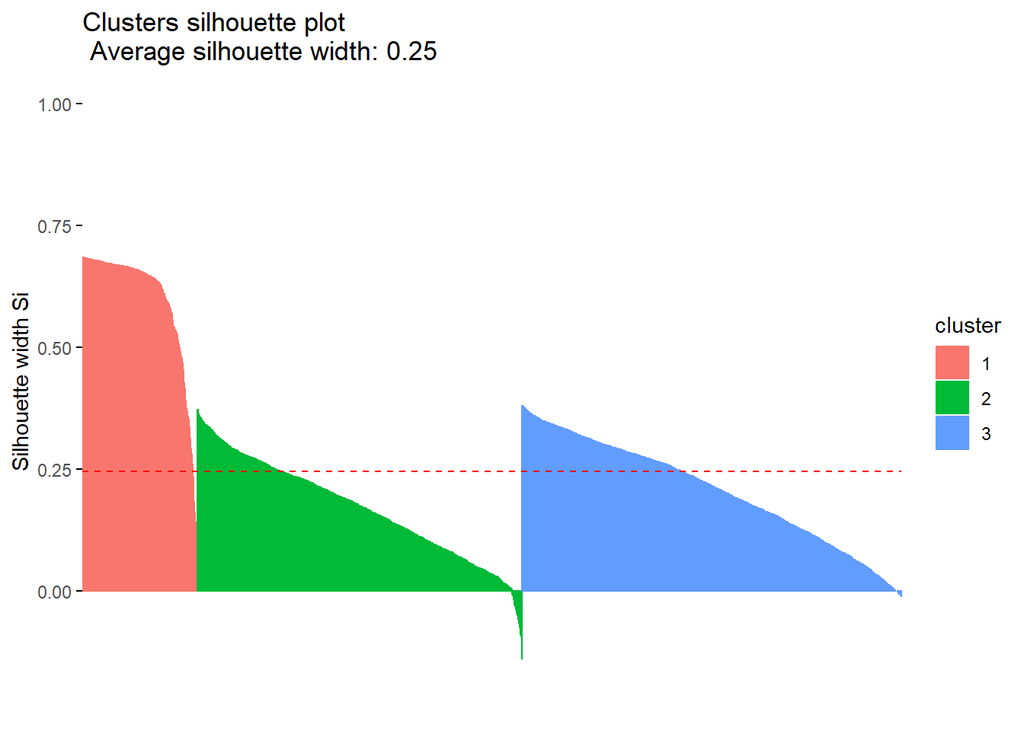

```r
#average silhouette for each clusters (3 clusters)
library(cluster)
avg_sil <- silhouette(kmeans.result$cluster,dist(brain_stroke)) #a dissimilarity object inheriting from class dist or coercible to one. If not specified, dmatrix must be.
fviz_silhouette(avg_sil)#k-means clustering with estimating k and initializations
```

The silhouette plot displays silhouette values for each data point in the dataset. Silhouette values measure how similar an object is to its own cluster (cohesion) compared to other clusters (separation). Silhouette values range from -1 to 1, where a high value indicates that the object is well matched to its own cluster and poorly matched to neighboring clusters, This plot shows that the avarege sillhoutte for 3 clusters = 0.25

#### BCubed when cluster size=3

```r
cluster_assignments <- c(kmeans.result$cluster)
ground_truth_labels <- c(datasetbrainstroke$stroke)

if (length(cluster_assignments) > length(ground_truth_labels)) {
  cluster_assignments <- cluster_assignments[1:length(ground_truth_labels)]
} else if (length(cluster_assignments) < length(ground_truth_labels)) {
  ground_truth_labels <- ground_truth_labels[1:length(cluster_assignments)]
}

data <- data.frame(cluster = cluster_assignments, label = ground_truth_labels)

# Function to calculate BCubed precision and recall
calculate_bcubed_metrics <- function(data) {
  n <- nrow(data)
  precision_sum <- 0
  recall_sum <- 0

  for (i in 1:n) {
    cluster <- data$cluster[i]
    label <- data$label[i]

# Count the number of items from the same category within the same cluster
same_category_same_cluster <- sum(data$label[data$cluster == cluster] == label)

# Count the total number of items in the same cluster
total_same_cluster <- sum(data$cluster == cluster)

# Count the total number of items with the same category
total_same_category <- sum(data$label == label)

# Calculate precision and recall for the current item and add them to the sums
precision_sum <- precision_sum + same_category_same_cluster /total_same_cluster
recall_sum <- recall_sum + same_category_same_cluster / total_same_category
  }

  # Calculate average precision and recall
  precision <- precision_sum / n
  recall <- recall_sum / n

  return(list(precision = precision, recall = recall))
}

# Calculate BCubed precision and recall
metrics <- calculate_bcubed_metrics(data)

# Extract precision and recall from the metrics
precision <- metrics$precision
recall <- metrics$recall

# Print the results
cat("BCubed Precision:", precision, "\n")
```

```
## BCubed Precision: 0.909903
```

```r
cat("BCubed Recall:", recall, "\n")
```

```
## BCubed Recall: 0.410234
```

A BCubed Precision of 0.910 suggests a high level of correctness in the clustering assignments, for the items grouped within these clusters, there’s a strong likelihood that they are correctly placed,the Recall score of 0.410 indicates that there’s a considerable gap in capturing all the relevant items within these clusters.

### K-means clustering, K= 4 Clusters

```r
# run k-means clustering to find 4 clusters
#set a seed for random number generation  to make the results reproducible
set.seed(8953)
kmeans.result <- kmeans(brain_stroke, 4)
# print the clusterng result
kmeans.result
```

```
## K-means clustering with 4 clusters of sizes 1456, 1428, 1412, 685
##
## Cluster means:
##     gender        age hypertension heart_disease ever_married work_type
## 1 1.613324  0.8387644   0.16964286   0.092032967     1.921016  2.103709
## 2 1.659664 -0.6186052   0.01960784   0.002100840     1.473389  1.936975
## 3 1.531870  0.5389144   0.14447592   0.097025496     1.894476  2.065156
## 4 1.468613 -1.6041165   0.00000000   0.001459854     1.000000  3.975182
##   Residence_type avg_glucose_level         bmi smoking_status
## 1       1.500687         0.8387644  0.31824487       1.657967
## 2       1.507003        -0.6186052 -0.06665006       1.934874
## 3       1.463173         0.5389144  0.33664313       3.493626
## 4       1.499270        -1.6041165 -1.23142824       1.125547
##
## Clustering vector:
```

[output cut: 144 more lines]

The K-means clustering resulted in 4 clusters with varying sizes: 1456, 1428, 1412, and 685 observations in each cluster, respectively. The cluster means provide insights into the characteristics of each group, indicating differences in features such as age, gender, hypertension, and other variables. The clustering vector assigns each observation to a specific cluster, reflecting the group to which it belongs. The within-cluster sum of squares (WSS) for each cluster shows the compactness of the clusters, with lower WSS values indicating more internally homogeneous groups. In this case, the WSS values are 3894.58, 3822.11, 4326.56, and 801.10 for clusters 1 to 4, respectively. The between-cluster sum of squares (54.4% of total SS) suggests good separation among the clusters. Interpretation of the results should consider both the WSS and between-cluster SS to determine the optimal balance of cluster cohesion and separation for the given context.

### total within-cluster-sum of square

```r
#total within-cluster-sum of square
twss <- sum(kmeans.result$withinss)
print(twss)
```

```
## [1] 12844.35
```

The total within-cluster sum of squares (WSS) for 4 clusters is 12844.35. The WSS is a key in the elbow method for evaluating the quality of clustering. A lower WSS signifies more compact and internally homogeneous clusters.

#### Visualize clustering (4 clusters)

```r
# visualize clustering (4 clusters)
install.packages("factoextra")
```

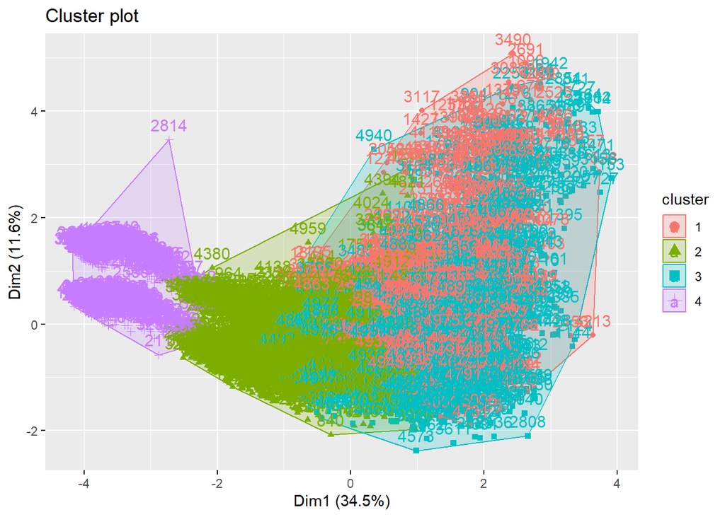

```r
library(factoextra)
fviz_cluster(kmeans.result, data = brain_stroke)
```

#### Another visualization (4 clusters)

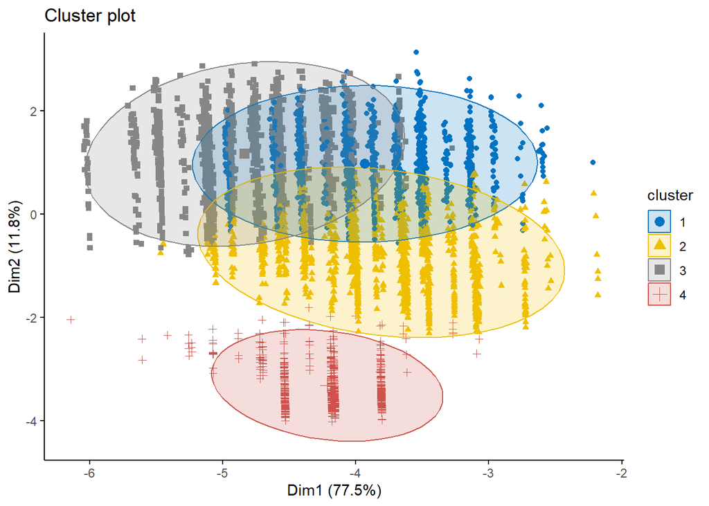

```r
library(factoextra)
fviz_cluster(list(data = brain_stroke, cluster = kmeans.result$cluster),
             ellipse.type = "norm", geom = "point", stand = FALSE,
             palette = "jco", ggtheme = theme_classic())
```

The visualisation shows 4 clusters are separated in the 2D space, with more overlap compared to the visualization of two clusters and three clusters. This overlap is particularly noticeable between cluster 1, cluster 2 and cluster 3. This observation implies that, especially considering the increased overlap, a potential optimal choice for the number of clusters (k) might still be 2.

#### Average silhouette for each clusters (4 clusters)

```
##   cluster size ave.sil.width
## 1       1 1456          0.20
## 2       2 1428          0.19
## 3       3 1412          0.15
## 4       4  685          0.58
```

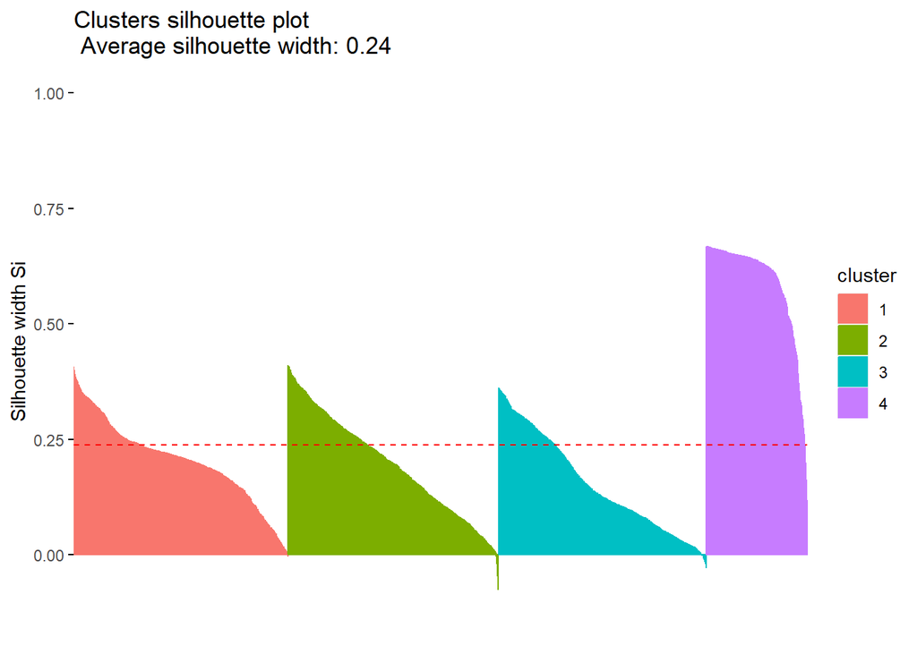

```r
#average silhouette for each clusters (4 cluster)
library(cluster)
avg_sil <- silhouette(kmeans.result$cluster,dist(brain_stroke)) #a dissimilarity object inheriting from class dist or coercible to one. If not specified, dmatrix must be.
fviz_silhouette(avg_sil)#k-means clustering with estimating k and initializations
```

#### BCubed when cluster size=4

```r
#BCubed when cluster size=4
cluster_assignments <- c(kmeans.result$cluster)
ground_truth_labels <- c(datasetbrainstroke$stroke)

if (length(cluster_assignments) > length(ground_truth_labels)) {
  cluster_assignments <- cluster_assignments[1:length(ground_truth_labels)]
} else if (length(cluster_assignments) < length(ground_truth_labels)) {
  ground_truth_labels <- ground_truth_labels[1:length(cluster_assignments)]
}

data <- data.frame(cluster = cluster_assignments, label = ground_truth_labels)

# Function to calculate BCubed precision and recall
calculate_bcubed_metrics <- function(data) {
  n <- nrow(data)
  precision_sum <- 0
  recall_sum <- 0

  for (i in 1:n) {
    cluster <- data$cluster[i]
    label <- data$label[i]

# Count the number of items from the same category within the same cluster
same_category_same_cluster <- sum(data$label[data$cluster == cluster] == label)

# Count the total number of items in the same cluster
total_same_cluster <- sum(data$cluster == cluster)

# Count the total number of items with the same category
total_same_category <- sum(data$label == label)

# Calculate precision and recall for the current item and add them to the sums
precision_sum <- precision_sum + same_category_same_cluster /total_same_cluster
recall_sum <- recall_sum + same_category_same_cluster / total_same_category
  }

  # Calculate average precision and recall
  precision <- precision_sum / n
  recall <- recall_sum / n

  return(list(precision = precision, recall = recall))
}

# Calculate BCubed precision and recall
metrics <- calculate_bcubed_metrics(data)

# Extract precision and recall from the metrics
precision <- metrics$precision
recall <- metrics$recall

# Print the results
cat("BCubed Precision:", precision, "\n")
```

```
## BCubed Precision: 0.9085269
```

```r
cat("BCubed Recall:", recall, "\n")
```

```
## BCubed Recall: 0.2755282
```

The BCubed Precision of 0.909 indicates highly accurate clustering assignments with four clusters. However, the low Recall score of 0.276 suggests a significant number of relevant items within these clusters might be overlooked.

### Total within-cluster sum of square (Elbow method)

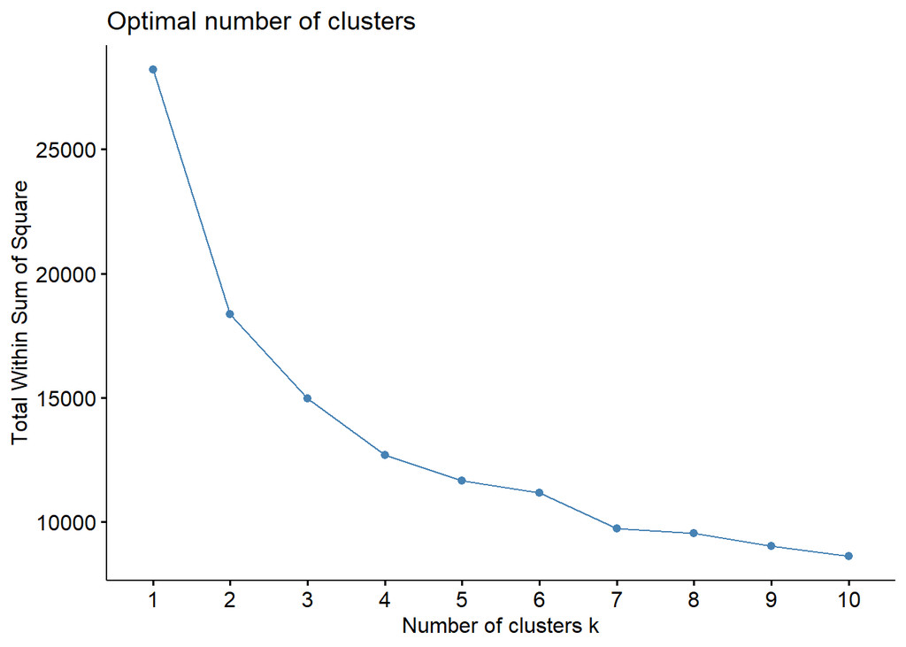

```r
library(factoextra)
fviz_nbclust(brain_stroke, kmeans, method = "wss")
```

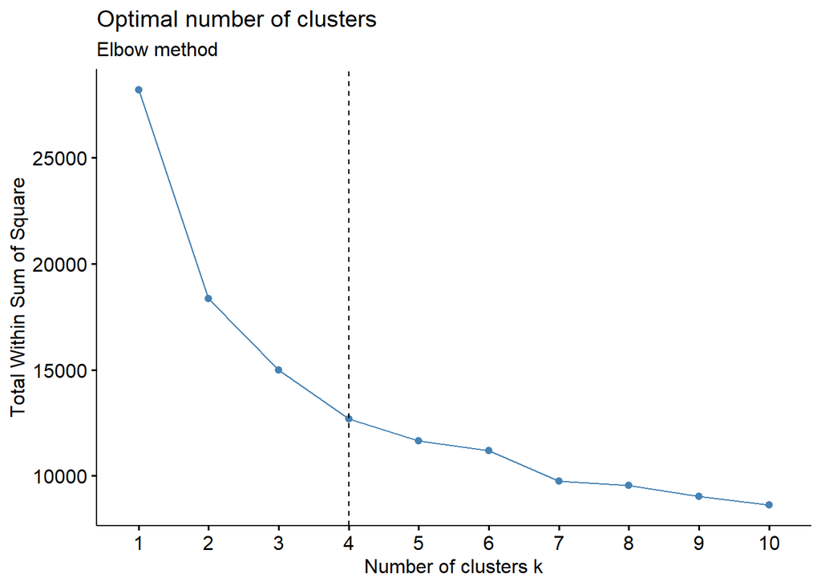

```r
# 3- Elbow method
#fviz_nbclust() with within cluster sums of squares (wss) method
library(factoextra)
fviz_nbclust(brain_stroke, kmeans, method = "wss") +
  geom_vline(xintercept = 4 , linetype = 2)+
  labs(subtitle = "Elbow method")
```

The plot depicts the elbow method used to determine the optimal number of clusters in k-means clustering for the brain stroke dataset. At k=2, the WSS is 18358.56, at k=3 it decreases to 14981.07, and at k= 4 it further reduces to 12844.35. The vertical dashed line at k=4 suggests a potential optimal number of clusters.

### Average Silhouette

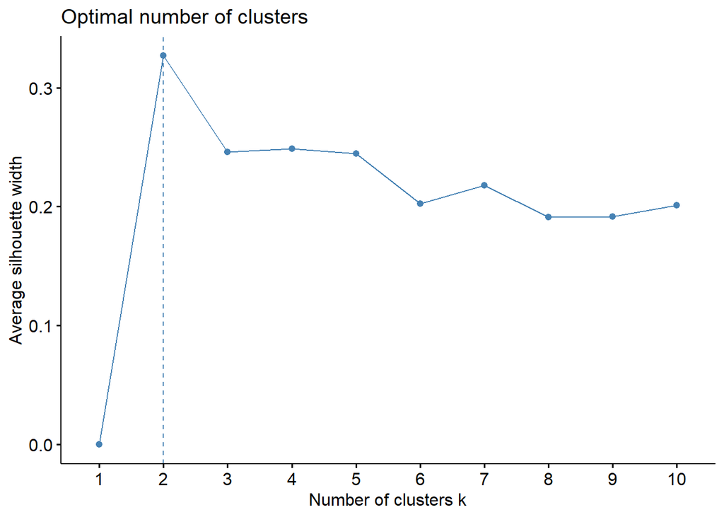

```r
library(factoextra)
fviz_nbclust(brain_stroke, kmeans, method = "silhouette")
```

The silhouette analysis for k-means clustering on the brain stroke dataset reveals that the average silhouette width is highest when using 2 clusters (0.33), indicating a well-defined and appropriate separation of data points. As the number of clusters increases to 3 (0.25) and 4 (0.24), the silhouette width slightly decreases, suggesting that a two-cluster solution is optimal for capturing the inherent structure in the data

##### This code performs k-means clustering multiple times with different initializations and estimates the optimal number of clusters. It then visualizes the clustering results using a cluster plot. This process can help determine the appropriate number of clusters and gain insights into the structure of the data.

```r
install.packages("fpc")
library(fpc)
#kmeansruns() : It calls  kmeans() to perform  k-means clustering
#It initializes the k-means algorithm several times with random points from the data set as means.
#It estimates the number of clusters by Calinski Harabasz index or average silhouette width
kmeansruns.result <- kmeansruns(brain_stroke)
kmeansruns.result
```

```
## K-means clustering with 2 clusters of sizes 3617, 1364
##
## Cluster means:
##     gender        age hypertension heart_disease ever_married work_type
## 1 1.593033  0.4738905  0.131600774  0.0757533868     1.869782  2.036771
## 2 1.558651 -1.2566437  0.002199413  0.0007331378     1.098240  3.006598
##   Residence_type avg_glucose_level       bmi smoking_status
## 1       1.488803         0.4738905  0.316517       2.464473
## 2       1.499267        -1.2566437 -0.839327       1.442082
##
## Clustering vector:
##    [1] 1 1 1 1 1 1 1 1 1 1 1 1 1 1 1 1 1 1 1 1 1 1 1 1 1 1 1 1 1 1 1 1 1 1 1 1 1
##   [38] 1 1 1 1 1 1 1 1 1 1 1 1 1 1 1 1 1 1 1 1 1 1 1 1 1 1 1 1 1 1 1 1 1 1 1 1 1
##   [75] 1 1 1 1 1 1 1 1 1 1 1 1 1 1 1 1 1 1 1 1 1 1 1 1 1 1 1 1 1 1 1 1 1 1 1 1 1
##  [112] 1 1 1 1 1 1 1 1 1 1 1 1 1 1 1 1 1 1 1 1 1 1 1 1 1 1 1 1 1 1 1 1 1 1 1 1 1
```

[output cut: 141 more lines]

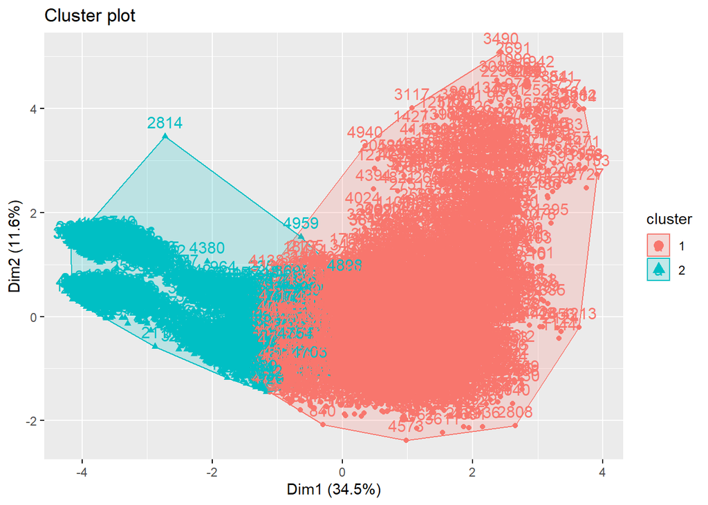

```r
fviz_cluster(kmeansruns.result, data = brain_stroke)
```

### Comparing the result of BCubed precision and recall

As the number of clusters increases from 2 to 4, the precision scores remain consistently high, hovering around the range of 0.907 to 0.910. However, the recall scores show a downward trend with an increase in the number of clusters. Recall decreases from 0.610 for k=2 down to 0.276 for k=4. This trend implies that while the model excels in accurately assigning items to clusters (evidenced by the high precision), it struggles more to capture all the relevant items within these clusters as the number of clusters increases. Balancing precision and recall becomes increasingly challenging as the cluster count rises.

1. **2 Clusters:**
   - High precision (0.9071407): Indicates that instances within each cluster are very similar, and there are fewer false positives.
   - Moderate recall (0.6096986): Suggests that not all instances of the true positive group are captured, but the captured instances are highly accurate.
2. **3 Clusters:**
   - Slightly higher precision (0.909903): Similar to 2 clusters, indicating high accuracy within each cluster.
   - Lower recall (0.410234): Indicates that more instances of the true positive group might be missed compared to 2 clusters.
3. **4 Clusters:**
   - Similar precision (0.9085269) to 2 and 3 clusters.
   - Lower recall (0.2755282): Indicates that more instances of the true positive group are being missed compared to 2 and 3 clusters.

Consideration for Classification Over Clustering

Our clusters are overlapping, it suggest that the dataset might be better suited for classification than clustering. Here’s why:

Inherent Structure: Clustering is for discovering natural structures, while classification thrives when clear class boundaries exist.

Visualization: Overlapping clusters might mean that our data lacks well-defined groupings, favoring classification.

Feature Alignment: Features chosen for clustering may not represent natural clusters but could align with class boundaries.

Consider Classification Models: Supervised models like decision trees or random forests may better capture the patterns in your labeled data.

#### Overall best cluster size

| Cluster size | k=2(Best) | k=3 | k=4 |
| --- | --- | --- | --- |
| Average S ilhouette width for each cluster | cluster1 = 0.39 cluster2 = 0.30 | cluster1 = 0.60 cluster2 = 0.17 cluster3 = 0.20 | cluster1 = 0.20 cluster2 = 0.19 cluster3 = 0.15 cluster4 = 0.58 |
| Average S ilhouette width for all clusters | 0.33 | 0.25 | 0.24 |
| Total w i t h i n-cluster sum of square | 18358.56 | 14981.07 | 12844.35 |
| BCubed precision | 0.9071407 | 0.909903 | 0.9085269 |
| BCubed recall | 0.6096986 | 0.410234 | 0.2755282 |
| V i s u alization | all of the figures is shown above | all of the figures is shown above | all of the figures is shown above |

packages and methods used

1- packages

library(fpc): The fpc package in R, which stands for “Flexible Procedures for Clustering,” provides various functions and procedures for cluster analysis. It is designed to offer flexibility in clustering tasks, including different methods for determining the number of clusters, assessing cluster validity, and performing clustering based on different algorithms.

library(factoextra): The factoextra package in R is designed to enhance and simplify the process of extracting and visualizing information from the results of multivariate analysis. Specifically, it provides functions for extracting and visualizing outputs from factor analysis (PCA, CA, MCA), clustering analysis (k-means, hierarchical clustering), and other multivariate techniques.

library(cluster): The cluster package in R provides a variety of functions and algorithms for cluster analysis, which is the process of grouping similar data points together.

2- methods

fviz_cluster() : This function is part of the factoextra package and is used for visualizing the results of clustering analyses.

fviz_silhouette(): This function, also part of the factoextra package, is specifically designed for visualizing silhouette widths.

kmeans(): This is a core function in R for performing k-means clustering.

fviz_nbclust(): This function in the factoextra package helps determine the optimal number of clusters by visualizing multiple clustering indices for different numbers of clusters.

## Classification

Classification is a powerful supervised machine learning approach designed to predict the category or class to which a new instance belongs. Unlike clustering, where the goal is to uncover inherent structures within data, classification leverages labeled datasets to train models and make predictions.

In the context of our analysis, we will explore a dataset related to brain stroke prediction using classification techniques. The objective is to train a model on existing data, learning patterns that link specific features to the likelihood of stroke occurrence. To develop a predictive model for our dataset, the objective is to forecast the class label “stroke,” where a value of 1 signifies an individual being at risk of experiencing a stroke, while a value of 0 denotes no risk. This prediction is based on various attributes available in the dataset. This predictive model can then be applied to new, unseen data to classify instances into relevant categories.

## Balance

Acknowledging the presence of imbalanced data in our dataset, we understand that addressing this imbalance is essential to improve the overall output quality. Therefore, we have applied the provided code to address this issue.

```r
# Install and load the caret package if not already installed
if (!requireNamespace("caret", quietly = TRUE)) {
  install.packages("caret")
}

# Load the caret package
library(caret)
# Check data dimensions
print(dim(datasetbrainstroke))##datasetbrainstroke
```

```
## [1] 4981   11
```

```r
# Check if 'stroke' is present
if (!"stroke" %in% colnames(datasetbrainstroke)) {
  stop("Column 'stroke' not found in the data.")
}

# Convert 'stroke' to a factor (if not already)
datasetbrainstroke$stroke <- as.factor(datasetbrainstroke$stroke)

# Upscale the data
datasetbrainstroke <- upSample(datasetbrainstroke[, -11], datasetbrainstroke$stroke, yname = "stroke")

# Checking the number of stroke/non-stroke observations
prop.table(table(datasetbrainstroke$stroke))
```

```
##
##   0   1
## 0.5 0.5
```

```r
table(datasetbrainstroke$stroke)
```

```
##
##    0    1
## 4733 4733
```

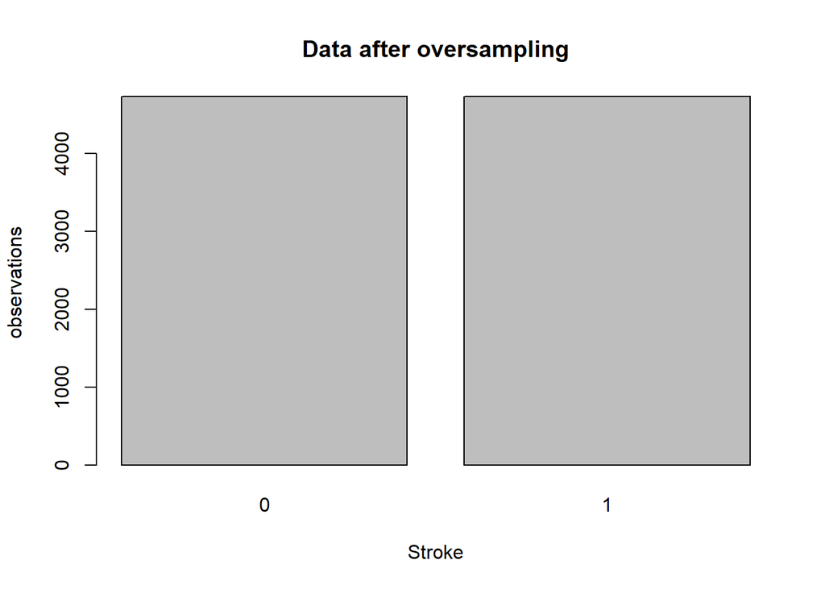

```r
# Create a barplot to visualize the distribution after oversampling
barplot(table(datasetbrainstroke$stroke), main = "Data after oversampling", xlab = "Stroke", ylab = "observations")
```

We picked the holdout method for classification because it’s good for checking how well the model works on new data in my dataset . It’s simple and quick, making it easier to compare different models and adjust settings. This method works well for medium to large datasets and situations where we need a straightforward evaluation.

In this part ,we will apply various techniques for attribute selection, including the Gini index, Gain ratio, and information gain, to build a decision tree model

### 1.Split the datasets into two subsets: Training(70%) and Testing(30%):

**Load necessary libraries**

```r
# Install required packages
packages_to_install <- c("ggthemes", "treemapify", "tree", "plotrix", "printr", "tidyverse", "partykit", "rpart.plot", "C50")
install.packages(packages_to_install, dependencies = TRUE)
# Load required packages
library(tidyverse)
library(dplyr)
library(ggplot2)
library(cowplot)
library(ggthemes)
library(treemapify)
library(tree)
library(plotrix)
library(printr)
library(partykit)
library(rpart)
library(rpart.plot)
library(C50)
library(pROC)
```

### A: Splitting the Data:

#### First: Splitting our data 70:30

```r
set.seed(190)#190
traindata70 <- createDataPartition(datasetbrainstroke$stroke, p=0.7,
                                 list=FALSE, times=1)
train70 <- datasetbrainstroke[traindata70,]
test70 <- datasetbrainstroke[-traindata70,]

# Checking that both the training and testing sets have the same label proportions.
prop_train70 <- train70 %>% select(stroke) %>% group_by(stroke) %>% summarize(n=n()) %>%
mutate(pct=round(prop.table(n), 2))

prop_test70 <- test70 %>% select(stroke) %>% group_by(stroke) %>% summarize(n=n()) %>%
mutate(pct=round(prop.table(n), 2))

prop_train70
```

| stroke | n | pct |
| --- | --- | --- |
| 0 | 3314 | 0.5 |
| 1 | 3314 | 0.5 |

```r
prop_test70
```

| stroke | n | pct |
| --- | --- | --- |
| 0 | 1419 | 0.5 |
| 1 | 1419 | 0.5 |

#### Second: Information Gine (ID3) - Tree model 70:30

```r
train70$stroke <- as.factor(train70$stroke)
tree_model <- rpart(stroke ~ ., data = train70, method = "class", parms = list(split = "information"))
print(tree_model)
```

```
## n= 6628
##
## node), split, n, loss, yval, (yprob)
##       * denotes terminal node
##
##  1) root 6628 3314 0 (0.5000000 0.5000000)
##    2) age< 0.4447888 2594  399 0 (0.8461835 0.1538165) *
##    3) age>=0.4447888 4034 1119 1 (0.2773922 0.7226078)
##      6) age< 1.062543 1554  646 1 (0.4157014 0.5842986)
##       12) bmi< -0.1838126 270   97 0 (0.6407407 0.3592593) *
##       13) bmi>=-0.1838126 1284  473 1 (0.3683801 0.6316199) *
##      7) age>=1.062543 2480  473 1 (0.1907258 0.8092742) *
```

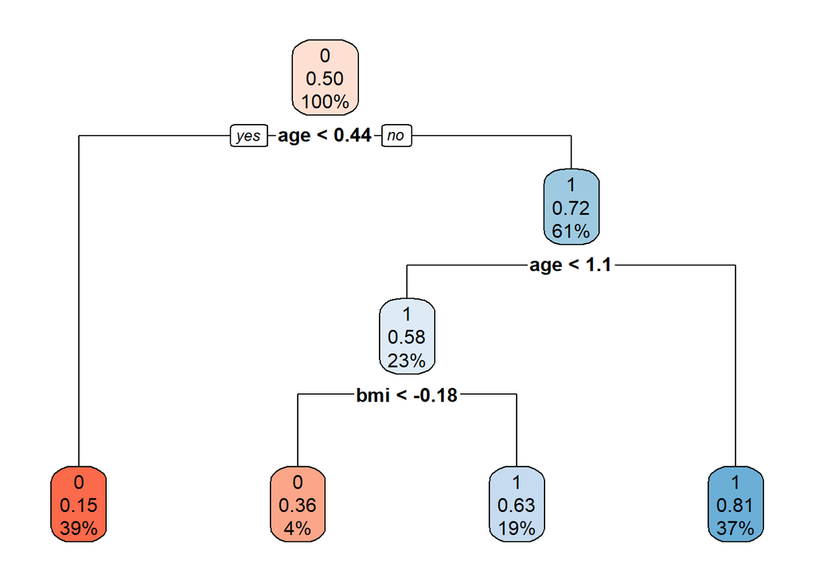

```r
rpart.plot(tree_model, box.palette = "RdBu")
```

#### Third: Information Gine (ID3) - Testing 70:30

```r
predictions1 <- predict(tree_model, newdata = test70, type = "class")
actual_labels1 <- test70$stroke
```

#### Fourth: Model Evaluation and Selection 70:30 for ID3

```r
confusion_matrix <- table(actual_labels1, predictions1)
print(confusion_matrix)
```

```
##               predictions1
## actual_labels1    0    1
##              0  982  437
##              1  233 1186
```

```r
TP <- confusion_matrix[1, 1]
TN <- confusion_matrix[2, 2]
FP <- confusion_matrix[2, 1]
FN <- confusion_matrix[1, 2]

accuracy <- ((TP + TN) / sum(confusion_matrix)) *100
precision <- (TP / (TP + FP) )*100
sensitivity <- (TP / (TP + FN) )*100
specificity <- (TN / (TN + FP) )*100
cat("Accuracy:", accuracy, "%\n")
```

```
## Accuracy: 76.39183 %
```

```r
cat("Precision:", precision, "%\n")
```

```
## Precision: 80.82305 %
```

```r
cat("Sensitivity (Recall):", sensitivity, "%\n")
```

```
## Sensitivity (Recall): 69.20366 %
```

```r
cat("Specificity:", specificity, "%\n")
```

```
## Specificity: 83.57999 %
```

#### Fifth: Gini index (CART) - Tree model 70:30

```r
tree_model<- rpart(stroke ~ ., data = train70, method = "class", parms = list(split = "gini"))
print(tree_model)
```

```
## n= 6628
##
## node), split, n, loss, yval, (yprob)
##       * denotes terminal node
##
##  1) root 6628 3314 0 (0.5000000 0.5000000)
##    2) age< 0.4447888 2594  399 0 (0.8461835 0.1538165) *
##    3) age>=0.4447888 4034 1119 1 (0.2773922 0.7226078)
##      6) age< 1.062543 1554  646 1 (0.4157014 0.5842986)
##       12) bmi< -0.1838126 270   97 0 (0.6407407 0.3592593) *
##       13) bmi>=-0.1838126 1284  473 1 (0.3683801 0.6316199) *
##      7) age>=1.062543 2480  473 1 (0.1907258 0.8092742) *
```

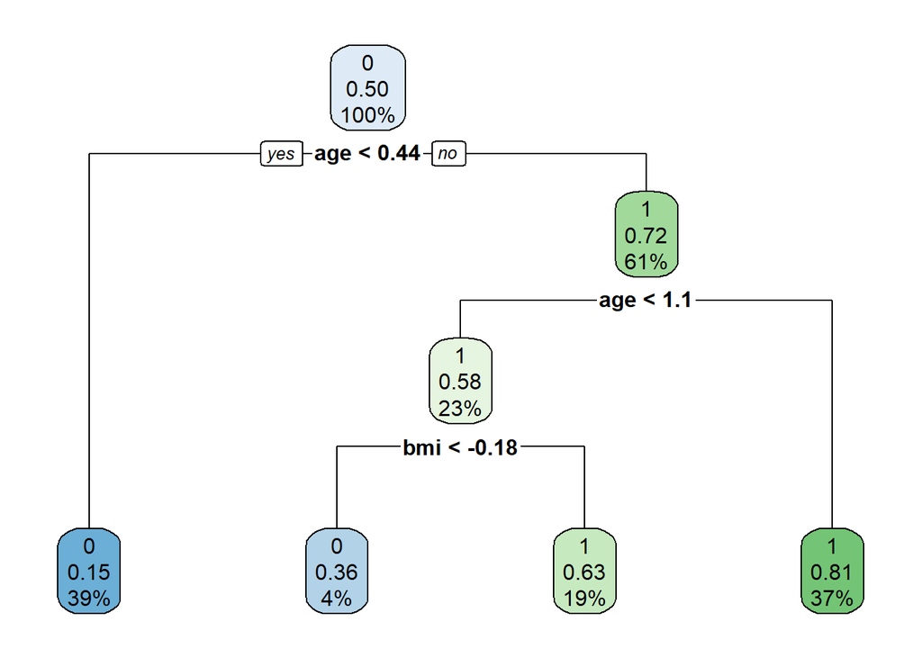

```r
rpart.plot(tree_model)
```

#### Sixth: Gini index (CART) - Testing 70:30

```r
predictions2 <- predict(tree_model, newdata = test70, type = "class")
actual_labels2 <- test70$stroke
```

#### Seventh: Model Evaluation and Selection 70:30 for Gini index

```r
confusion_matrix <- table(actual_labels2, predictions2)
print(confusion_matrix)
```

```
##               predictions2
## actual_labels2    0    1
##              0  982  437
##              1  233 1186
```

```r
TP <- confusion_matrix[1, 1]
TN <- confusion_matrix[2, 2]
FP <- confusion_matrix[2, 1]
FN <- confusion_matrix[1, 2]

accuracy <- ((TP + TN) / sum(confusion_matrix)) *100
precision <- (TP / (TP + FP) )*100
sensitivity <- (TP / (TP + FN) )*100
specificity <- (TN / (TN + FP) )*100
cat("Accuracy:", accuracy, "%\n")
```

```
## Accuracy: 76.39183 %
```

```r
cat("Precision:", precision, "%\n")
```

```
## Precision: 80.82305 %
```

```r
cat("Sensitivity (Recall):", sensitivity, "%\n")
```

```
## Sensitivity (Recall): 69.20366 %
```

```r
cat("Specificity:", specificity, "%\n")
```

```
## Specificity: 83.57999 %
```

**findings:**

#### Eighth: Gain ratio (C5.0) - Tree model 70:30

[figure not shown]

```r
# Convert stroke to a factor variable
train70$stroke <- as.factor(train70$stroke)

# Set C5.0 control parameters
c5_control <- C5.0Control(winnow = TRUE, CF = 0.01, minCases = 35)

# Create a formula for the C5.0 model
myFormula <- stroke ~ age + hypertension +ever_married+avg_glucose_level

# Fit the C5.0 decision tree model
c50_model <- C5.0(myFormula, data = train70, control = c5_control)

# Plot the C5.0 decision tree
plot(c50_model, control = list(maxdepth = 3))
```

#### Ninth: Gain ratio (C5.0) - Testing 70:30

```r
predictions3 <- predict(c50_model, newdata = test70, type = "class")
actual_labels3 <- test70$stroke
```

#### Tenth: Model Evaluation and Selection 70:30 for Gain ratio

```r
confusion_matrix <- table(actual_labels3, predictions3)
print(confusion_matrix)
```

```
##               predictions3
## actual_labels3    0    1
##              0  973  446
##              1  202 1217
```

```r
TP <- confusion_matrix[1, 1]
TN <- confusion_matrix[2, 2]
FP <- confusion_matrix[2, 1]
FN <- confusion_matrix[1, 2]

accuracy <- ((TP + TN) / sum(confusion_matrix)) *100
precision <- (TP / (TP + FP) )*100
sensitivity <- (TP / (TP + FN) )*100
specificity <- (TN / (TN + FP) )*100
cat("Accuracy:", accuracy, "%\n")
```

```
## Accuracy: 77.16702 %
```

```r
cat("Precision:", precision, "%\n")
```

```
## Precision: 82.80851 %
```

```r
cat("Sensitivity (Recall):", sensitivity, "%\n")
```

```
## Sensitivity (Recall): 68.56942 %
```

```r
cat("Specificity:", specificity, "%\n")
```

```
## Specificity: 85.76462 %
```

**findings:**

#### First: Splitting our data 80:20

```r
set.seed(1242)
traindata80 <- createDataPartition(datasetbrainstroke$stroke, p=0.8,
                                 list=FALSE, times=1)
train80 <- datasetbrainstroke[traindata80,]
test80 <- datasetbrainstroke[-traindata80,]

# Checking that both the training and testing sets have the same label proportions.
prop_train80 <- train80 %>% select(stroke) %>% group_by(stroke) %>% summarize(n=n()) %>%
mutate(pct=round(prop.table(n), 2))

prop_test80 <- test80 %>% select(stroke) %>% group_by(stroke) %>% summarize(n=n()) %>%
mutate(pct=round(prop.table(n), 2))

prop_train80
```

| stroke | n | pct |
| --- | --- | --- |
| 0 | 3787 | 0.5 |
| 1 | 3787 | 0.5 |

```r
prop_test80
```

| stroke | n | pct |
| --- | --- | --- |
| 0 | 946 | 0.5 |
| 1 | 946 | 0.5 |

#### Second: Information Gine (ID3) - Tree model 80:20

```r
train80$stroke <- as.factor(train80$stroke)
tree_model <- rpart(stroke ~ ., data = train80, method = "class", parms = list(split = "information"))
print(tree_model)
```

```
## n= 7574
##
## node), split, n, loss, yval, (yprob)
##       * denotes terminal node
##
##   1) root 7574 3787 0 (0.5000000 0.5000000)
##     2) age< 0.1800373 2341  236 0 (0.8991884 0.1008116) *
##     3) age>=0.1800373 5233 1682 1 (0.3214217 0.6785783)
##       6) age< 1.062543 2360 1120 1 (0.4745763 0.5254237)
##        12) bmi< -0.1838126 444  137 0 (0.6914414 0.3085586) *
##        13) bmi>=-0.1838126 1916  813 1 (0.4243215 0.5756785)
##          26) heart_disease< 0.5 1663  762 1 (0.4582081 0.5417919)
##            52) bmi>=0.523061 704  313 0 (0.5553977 0.4446023)
##             104) bmi< 0.6408733 67    0 0 (1.0000000 0.0000000) *
##             105) bmi>=0.6408733 637  313 0 (0.5086342 0.4913658)
##               210) age>=0.7536657 117   28 0 (0.7606838 0.2393162) *
##               211) age< 0.7536657 520  235 1 (0.4519231 0.5480769)
##                 422) age< 0.5330394 226   79 0 (0.6504425 0.3495575) *
##                 423) age>=0.5330394 294   88 1 (0.2993197 0.7006803) *
##            53) bmi< 0.523061 959  371 1 (0.3868613 0.6131387) *
##          27) heart_disease>=0.5 253   51 1 (0.2015810 0.7984190) *
##       7) age>=1.062543 2873  562 1 (0.1956143 0.8043857) *
```

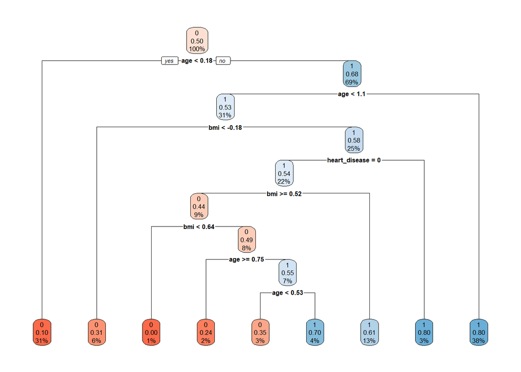

```r
rpart.plot(tree_model, box.palette = "RdBu")
```

#### Third: Information Gine (ID3) - Testing 80:20

```r
predictions4 <- predict(tree_model, newdata = test80, type = "class")
actual_labels4 <- test80$stroke
```

#### Fourth: Model Evaluation and Selection 80:20 for ID3

```r
confusion_matrix <- table(actual_labels4, predictions4)
print(confusion_matrix)
```

```
##               predictions4
## actual_labels4   0   1
##              0 691 255
##              1 132 814
```

```r
TP <- confusion_matrix[1, 1]
TN <- confusion_matrix[2, 2]
FP <- confusion_matrix[2, 1]
FN <- confusion_matrix[1, 2]

accuracy <- ((TP + TN) / sum(confusion_matrix)) *100
precision <- (TP / (TP + FP) )*100
sensitivity <- (TP / (TP + FN) )*100
specificity <- (TN / (TN + FP) )*100
cat("Accuracy:", accuracy, "%\n")
```

```
## Accuracy: 79.54545 %
```

```r
cat("Precision:", precision, "%\n")
```

```
## Precision: 83.96112 %
```

```r
cat("Sensitivity (Recall):", sensitivity, "%\n")
```

```
## Sensitivity (Recall): 73.0444 %
```

```r
cat("Specificity:", specificity, "%\n")
```

```
## Specificity: 86.04651 %
```

#### Fifth: Gini index (CART) - Tree model 80:20

```r
tree_model <- rpart(stroke ~ ., data = train80, method = "class", parms = list(split = "gini"))
print(tree_model)
```

```
## n= 7574
##
## node), split, n, loss, yval, (yprob)
##       * denotes terminal node
##
##  1) root 7574 3787 0 (0.5000000 0.5000000)
##    2) age< 0.4447888 2941  471 0 (0.8398504 0.1601496) *
##    3) age>=0.4447888 4633 1317 1 (0.2842651 0.7157349)
##      6) age< 1.062543 1760  755 1 (0.4289773 0.5710227)
##       12) bmi< -0.1838126 307  109 0 (0.6449511 0.3550489) *
##       13) bmi>=-0.1838126 1453  557 1 (0.3833448 0.6166552) *
##      7) age>=1.062543 2873  562 1 (0.1956143 0.8043857) *
```

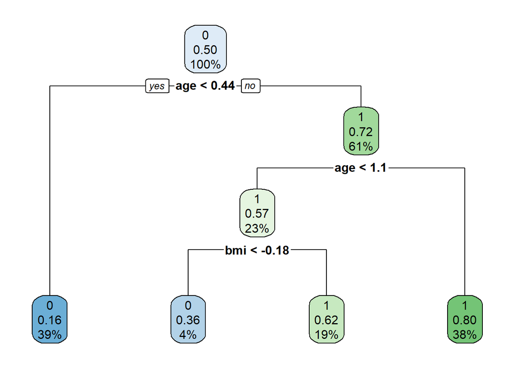

```r
rpart.plot(tree_model)
```

#### Sixth: Gini index (CART) - Testing 80:20

```r
predictions5 <- predict(tree_model, newdata = test80, type = "class")
actual_labels5 <- test80$stroke
```

#### Seventh: Model Evaluation and Selection 80:20 for Gini index

```r
confusion_matrix <- table(actual_labels5, predictions5)
print(confusion_matrix)
```

```
##               predictions5
## actual_labels5   0   1
##              0 682 264
##              1 149 797
```

```r
TP <- confusion_matrix[1, 1]
TN <- confusion_matrix[2, 2]
FP <- confusion_matrix[2, 1]
FN <- confusion_matrix[1, 2]

accuracy <- ((TP + TN) / sum(confusion_matrix)) *100
precision <- (TP / (TP + FP) )*100
sensitivity <- (TP / (TP + FN) )*100
specificity <- (TN / (TN + FP) )*100
cat("Accuracy:", accuracy, "%\n")
```

```
## Accuracy: 78.17125 %
```

```r
cat("Precision:", precision, "%\n")
```

```
## Precision: 82.0698 %
```

```r
cat("Sensitivity (Recall):", sensitivity, "%\n")
```

```
## Sensitivity (Recall): 72.09302 %
```

```r
cat("Specificity:", specificity, "%\n")
```

```
## Specificity: 84.24947 %
```

**findings:**

#### Eighth: Gain ratio (C5.0) - Tree model 80:20

[figure not shown]

```r
# Convert stroke to a factor variable
train80$stroke <- as.factor(train80$stroke)

# Set C5.0 control parameters
c5_control <- C5.0Control(winnow = TRUE, CF = 0.01, minCases = 40)

# Create a formula for the C5.0 model
myFormula <- stroke ~ age + hypertension +ever_married+avg_glucose_level

# Fit the C5.0 decision tree model
c50_model <- C5.0(myFormula, data = train80, control = c5_control)

# Plot the C5.0 decision tree
plot(c50_model, control = list(maxdepth = 3))
```